Capítulo

# Compatibilidade Eletromagnética

Compatibilidade Eletromagnética

IFSC · Prof. Laio Oriel Seman

Apostila de curso · 80 horas

# Compatibilidade Eletromagnética

Uma jornada progressiva da teoria aos experimentos computacionais.

IFSC · Prof. Laio Oriel Seman

# Compatibilidade Eletromagnética

# 1. Aspectos Econômicos da Compatibilidade Eletromagnética

> Compatibilidade Eletromagnética — Apostila de Curso  
> Tópicos: Custos da EMC · Análise de ROI · Normas e Regulamentações · Estudos de Caso · Design-for-EMC · Exercícios em Python (80 horas)

## 1.1 Antes de começar

Ao final, você deve conseguir comparar prevenção, pré-conformidade, redesign, atraso e falha em campo por custo esperado — sem tratar valores ilustrativos como dados universais. **Diagnóstico:** qual decisão muda se a probabilidade de falha cair pela metade, mas o custo de teste dobrar? **Evidência mínima:** explicitar premissas, fazer análise de sensibilidade e justificar uma decisão *design-for-EMC*.

## 1.2 Introdução à EMC e seu Contexto Econômico

### 1.2.1 O que é Compatibilidade Eletromagnética

A **Compatibilidade Eletromagnética (EMC)** é a capacidade de um equipamento ou sistema eletroeletrônico funcionar adequadamente em seu ambiente eletromagnético sem introduzir interferências eletromagnéticas intoleráveis a outros equipamentos nesse mesmo ambiente.

A definição formal do **IEEE Std 100** (Standard Dictionary of Electrical and Electronic Terms) é:

> A capacidade de um equipamento desempenhar sua função sem sofrer degradação por causa de interferências eletromagnéticas produzidas por outros equipamentos, e a capacidade de não produzir interferências eletromagnéticas intoleráveis a outros equipamentos.

Em linguagem mais precisa:

$$ \boxed{\text{EMC} \equiv \text{EMI} + \text{EMS}} $$

onde:

- **EMI** (*Electromagnetic Interference*) — emissão: a capacidade do equipamento de **não gerar** interferências;
- **EMS** (*Electromagnetic Susceptibility* ou *Immunity*) — imunidade: a capacidade do equipamento de **não ser afetado** por interferências externas.

Um sistema EMC-compatível satisfaz simultaneamente:

$$ E_{\text{emitido}}(f) \leq L_{\text{limite}}(f) \qquad\text{e}\qquad I_{\text{recebido}}(f) < I_{\text{limiar}}(f) $$

para toda frequência $f$ no domínio de interesse, onde $E_{\text{emitido}}$ é o espectro de emissão, $L_{\text{limite}}$ é o limite regulatório, $I_{\text{recebido}}$ é o nível de interferência acoplado ao sistema e $I_{\text{limiar}}$ é o limiar de degradação funcional.

### 1.2.2 Por que EMC é um Problema Econômico

A EMC não é apenas uma questão técnica — é uma **variável econômica crítica** que afeta diretamente:

1. **Recalls de produtos**: quando um produto certificado falha em campo, o custo de recall pode exceder em ordens de grandeza o investimento original em projeto EMC.
2. **Multas regulatórias**: agências como a FCC (EUA), ANATEL (Brasil) e a Comissão Europeia aplicam multas significativas por não-conformidade.
3. **Atrasos de lançamento**: cada trimestre de atraso no *time-to-market* representa perda de receita potencial e vantagem competitiva.
4. **Custo de garantia**: falhas de EMC em campo geram chamados de suporte, devoluções e danos à marca.

**Modelo didático, não lei empírica universal:** correções tardias tendem a envolver mais artefatos, estoque e cronograma. Uma curva exponencial pode representar essa ideia:

$$ C_{\text{corr}}(t) = C_0 \cdot e^{k(t-t_0)} $$

onde $C_0$ é o custo inicial, $k$ é parâmetro a ser **calibrado com dados da organização** e $t_0$ é a referência. Não trate “fase” como unidade física nem use uma faixa genérica de $k$ como previsão.

### 1.2.3 Custo do *Compliance* vs. Custo do Não-*Compliance*

Defina:

- $C_{\text{comp}}$ = custo total de conformidade EMC (projeto + teste + certificação)
- $C_{\text{não-comp}}$ = custo esperado de não-conformidade (multas + recalls + perda de receita + reputação)

A decisão econômica ótima satisfaz:

$$ \boxed{C_{\text{comp}}^{*} = \arg\min_{C_{\text{comp}}} \bigl[C_{\text{comp}} + \mathbb{E}[C_{\text{não-comp}} \mid \text{nível de compliance alcançado por } C_{\text{comp}}]\bigr]} $$

Tabela de cenários ilustrativos para análise de sensibilidade:

| Fase do Projeto | Custo Relativo de Correção | Fator de Multiplicação |
| --- | --- | --- |
| Conceito / Especificação | $1\times$ (base) | 1,0 |
| Projeto Conceitual | $2\text{--}3\times$ | $2\text{--}3$ |
| Projeto Detalhado | $5\text{--}10\times$ | $5\text{--}10$ |
| Protótipo | $10\text{--}50\times$ | $10\text{--}50$ |
| Pré-produção | $50\text{--}100\times$ | $50\text{--}100$ |
| Produção / Campo | $100\text{--}1000\times$ | $100\text{--}1000$ |

**Observação:** sem fonte e base de dados do projeto, esses multiplicadores são hipóteses. Substitua-os por faixas otimista/base/pessimista e registre moeda, ano-base, volume e itens incluídos.

### 1.2.4 Ciclo de Vida do Produto e Onde a EMC Entra

O ciclo de vida de um produto eletroeletrônico típico compreende as seguintes fases:

$$ \text{Conceito} \to \text{Projeto Conceitual} \to \text{Projeto Detalhado} \to \text{Protótipo} \to \text{Validação} \to \text{Certificação} \to \text{Produção} \to \text{Campo} \to \text{Pós-venda} $$

A EMC deve ser considerada em **cada fase**, com diferentes níveis de profundidade:

1. **Conceito**: definição dos requisitos EMC (normas aplicáveis, limites, nível de ambiente).
2. **Projeto Conceitual**: escolha de arquitetura, topologias de blindagem, técnicas de filtração.
3. **Projeto Detalhado**: layout de PCB, projeto de gabinetes, especificação de componentes de supressão.
4. **Protótipo**: medições preliminares, identificação de problemas, correções.
5. **Validação**: testes de conformidade em laboratório acreditado, ajustes finos.
6. **Certificação**: submissão a organismo notificado, obtenção de marcação.
7. **Produção**: controle de qualidade EMC, testes de lote.
8. **Campo**: monitoramento de falhas, feedback para próximas iterações.

$$ \boxed{\text{Investimento em EMC na fase } t \propto \frac{1}{\text{Margem de correção disponível em } t}} $$

Quanto mais cedo a EMC é considerada, maior a margem de correção disponível e menor o custo.

## 1.3 Análise de Custos da Compatibilidade Eletromagnética

### 1.3.1 Custo de Projeto Preventivo

O **custo de projeto preventivo** inclui todas as atividades realizadas antecipadamente para garantir a compatibilidade eletromagnética:

$$ C_{\text{design}} = C_{\text{consultoria}} + C_{\text{ferramentas}} + C_{\text{treinamento}} + C_{\text{simulação}} + C_{\text{componentes}} $$

onde:

- $C_{\text{consultoria}}$: engenheiros de EMC dedicados ao projeto.
- $C_{\text{ferramentas}}$: softwares de simulação (SI/PI/EMC), instrumentação.
- $C_{\text{treinamento}}$: qualificação da equipe de projeto.
- $C_{\text{simulação}}$: horas de simulação EM (FDTD, FEM, Method of Moments).
- $C_{\text{componentes}}$: filtros, blindagens, materiais absorventes, conectores blindados.

Para um produto eletrônico de porte médio, estimativas típicas:

$$ C_{\text{design}} \approx \alpha \cdot P_{\text{base}} $$

onde $P_{\text{base}}$ é o custo base do projeto (sem EMC) e $\alpha$ é um fator de acréscimo que varia entre $3\%$ e $15\%$, dependendo do setor e dos requisitos.

**Valor típico de $\alpha$ por setor**:

| Setor | $\alpha_{\min}$ | $\alpha_{\max}$ | Comentário |
| --- | --- | --- | --- |
| Consumidor | 3% | 7% | Limites mais brandos, volumes altos |
| Industrial | 7% | 12% | Ambiente hostil, requisitos rigorosos |
| Automotivo | 10% | 18% | VDA 5083, ISO 11452, volumes enormes |
| Médico | 10% | 20% | IEC 60601-1-2, risco de vida |
| Aeroespacial | 12% | 25% | MIL-STD-461, custo de falha extremo |

### 1.3.2 Custo de Correção e a Curva Exponencial

O **custo de correção** $C_{\text{corr}}$ é o custo adicional necessário quando um problema de EMC é identificado após o ponto ideal de correção. A dependência temporal segue um modelo exponencial:

$$ \boxed{C_{\text{corr}}(t) = C_{\text{corr}}(t_0) \cdot e^{k(t - t_0)}} $$

Onde $t_0$ é a fase de conceito e $k$ é o parâmetro de "inflação de custo":

- Produtos simples: $k \approx 0{,}8$ por fase
- Produtos complexos: $k \approx 1{,}5\text{--}2{,}0$ por fase
- Sistemas integrados (SoC + RF + mecânica): $k \approx 2{,}0\text{--}3{,}0$ por fase

A **razão de correção** $R(t)$, definida como o custo de corrigir na fase $t$ dividido pelo custo de prevenir na fase $t_0$, é:

$$ R(t) = \frac{C_{\text{corr}}(t)}{C_{\text{design}}} = e^{k(t-t_0)} $$

Para um produto com $k=1{,}5$ descoberto na fase de protótipo ($t-t_0 = 3$ fases):

$$ R(3) = e^{1{,}5 \times 3} = e^{4{,}5} \approx 90 $$

Ou seja, corrigir no protótipo custa ~90× mais que prevenir no conceito.

### 1.3.3 Modelo de Custo Total

O **custo total de EMC** para um produto ao longo de seu ciclo de vida é modelado por:

$$ \boxed{C_{\text{total}} = C_{\text{design}} + C_{\text{test}} + C_{\text{corr}} + C_{\text{failure}}} $$

Onde cada componente é definido a seguir.

#### 1.3.3.1 Custo de teste ($C_{\text{test}}$)

Inclui todos os custos de medição e certificação:

$$ C_{\text{test}} = C_{\text{pre-test}} + C_{\text{cert-test}} + C_{\text{re-test}} + C_{\text{ongoing}} $$

- $C_{\text{pre-test}}$: testes de pré-conformidade em laboratório interno ou terceirizado.
- $C_{\text{cert-test}}$: testes de certificação em organismo acreditado (FCC, CE, etc.).
- $C_{\text{re-test}}$: retestes após correções.
- $C_{\text{ongoing}}$: testes de produção (Q.C.) em linha.

Estimativas típicas:

| Tipo de Teste | Custo Unitário (USD) | Frequência |
| --- | --- | --- |
| Pré-teste interno | 5.000 -- 15.000 | 2--5 vezes |
| Certificação FCC | 10.000 -- 30.000 | 1 vez |
| Certificação CE/CISPR | 15.000 -- 40.000 | 1 vez |
| Teste de conformidade automotiva | 20.000 -- 60.000 | 1--3 vezes |
| Teste de linha de produção | 500 -- 2.000 / unidade | Cada unidade |

#### 1.3.3.2 Custo de falha ($C_{\text{failure}}$)

O custo esperado de falha de EMC em campo é modelado como:

$$ C_{\text{failure}} = N \cdot p_f \cdot c_f $$

Onde:

- $N$ = número de unidades vendidas
- $p_f$ = probabilidade de falha de EMC em campo
- $c_f$ = custo médio por falha (garantia + suporte + reputação)

A probabilidade $p_f$ é função do esforço de projeto e teste:

$$ p_f = p_0 \cdot e^{-\beta \cdot E} $$

onde $p_0$ é uma probabilidade-base, $E$ deve ter unidade declarada e $\beta$ deve ter unidade inversa para que $\beta E$ seja adimensional. A exponencial é uma hipótese de resposta, a ser calibrada; investimento financeiro sozinho não determina probabilidade técnica.

#### 1.3.3.3 Modelo completo

Substituindo:

$$ \boxed{C_{\text{total}}(E) = \underbrace{\alpha \cdot P_{\text{base}}}_{C_{\text{design}}(E)} + \underbrace{C_{\text{test}}(E)}_{\text{testes}} + \underbrace{C_{\text{corr}}(E)}_{\text{correções}} + \underbrace{N \cdot p_0 \cdot e^{-\beta E} \cdot c_f}_{C_{\text{failure}}(E)}} $$

O ótimo de investimento $E^{*}$ satisfaz:

$$ \frac{dC_{\text{total}}}{dE}\bigg|_{E=E^{*}} = 0 $$

### 1.3.4 ROI de Investimento em EMC

O **Retorno sobre Investimento (ROI)** de um programa EMC é definido como:

$$ \boxed{\text{ROI} = \frac{B - C}{C} \times 100\%} $$

Onde:

- $C = C_{\text{design}} + C_{\text{test}}$ = investimento total em EMC
- $B = \mathbb{E}[C_{\text{failure}\, \text{sem EMC}}] - \mathbb{E}[C_{\text{failure}\, \text{com EMC}}]$ = benefícios (custos de falha evitados)

$$ B = N \cdot c_f \cdot p_0 \cdot (1 - e^{-\beta E}) $$

Logo:

$$ \boxed{\text{ROI} = \frac{N \cdot c_f \cdot p_0 \cdot (1 - e^{-\beta E}) - E}{E} \times 100\%} $$

**Exemplo numérico**: Para um dispositivo médico ($N = 10.000$ unidades, $c_f = 50.000$ USD/falha, $p_0 = 0{,}10$, $\beta = 0{,}10$/USD$k$, $E = 200$k USD):

$$ B = 10000 \times 50000 \times 0{,}10 \times (1 - e^{-0{,}10 \times 200}) = 50.000.000 \times (1 - e^{-20}) $$

$$ B \approx 50.000.000 \times (1 - 2{,}06\times10^{-9}) \approx 50.000.000\ \text{USD} $$

$$ \text{ROI} = \frac{50.000.000 - 200.000}{200.000} \times 100\% = \frac{49.800.000}{200.000} \times 100\% = 24.900\% $$

**Interpretação:** o ROI enorme é consequência direta de supor 1.000 falhas esperadas a 50 mil USD cada e quase eliminação total por uma exponencial não calibrada. É um cenário, não evidência de ROI típico. Faça sensibilidade em $p_0,c_f,\beta$ e dependência/correlação das falhas.

### 1.3.5 Valor Presente Líquido de Investimentos EMC

Quando custos e benefícios se distribuem ao longo do tempo, usamos o **valor presente** (VP):

$$ \boxed{PV = \frac{FV}{(1+r)^n}} $$

Onde $FV$ é o valor futuro, $r$ a taxa de desconto e $n$ o número de períodos.

O **Valor Presente Líquido (VPL)** do programa EMC:

$$ \boxed{\text{VPL}=-C_0+\sum_{t=1}^{T}\frac{B_t-C_t}{(1+r)^t}} $$

onde $C_0$ fica fora da soma e $B_t,C_t$ são fluxos posteriores. Alternativamente, inclua $t=0$ na soma e não subtraia $C_0$ outra vez.

Condição de viabilidade: $\text{VPL} > 0$.

## 1.4 Normas e Regulamentações — Barreiras Comerciais

### 1.4.1 Panorama Global de Normas EMC

A conformidade EMC é **requisito legal** para comercialização na maioria dos países. O panorama normativo é fragmentado por região:

#### 1.4.1.1 Estados Unidos — FCC

A **Federal Communications Commission (FCC)** regula emissões eletromagnéticas nos EUA. As partes relevantes são:

$$ \boxed{20\log_{10}\!\left(\frac{V_{\text{ruído}}}{1\,\mu\text{V}}\right) \leq 79 - 20\log_{10}(f_{\text{MHz}})\quad\text{para }0{,}15\leq f \leq 0{,}5\,\text{MHz}} $$

$$ \boxed{73\ \text{dB}\mu\text{V}\quad\text{para }0{,}5 < f \leq 5\,\text{MHz}} $$

$$ \boxed{73 - 10\log_{10}\!\left(\frac{B}{1\,\text{kHz}}\right)\ \text{dB}\mu\text{V}\quad\text{para }5 < f \leq 30\,\text{MHz}} $$

Classe B (residencial) é ~20--30 dB mais restritiva.

#### 1.4.1.2 Europa — CE / CISPR

A marca **CE** exige conformidade com as diretivas europeias, harmonizadas por normas **CISPR** (Comité International Spécial des Perturbations Electriques) e **IEC**:

- **CISPR 32**: multimídia equipment — emissões.
- **CISPR 35**: equipamentos de TI e áudio/vídeo — emissões e imunidade.
- **IEC 61000-6-2**: imunidade para ambiente industrial.
- **IEC 61000-6-4**: emissões para ambiente industrial.

O limite CISPR 32 Classe A de radiação (campo próximo, 10 m):

$$ \boxed{E(f) \leq \begin{cases} 30\ \text{dB}\mu\text{V/m} & 30\leq f < 230\,\text{MHz} \\ 37\ \text{dB}\mu\text{V/m} & 230\leq f < 1000\,\text{MHz} \end{cases}} $$

#### 1.4.1.3 Normas Internacionais — IEC / ANSI

O **IEC** (International Electrotechnical Commission) publica a série **IEC 61000** (Compatibilidade Eletromagnética), base para a maioria das normas nacionais:

- **IEC 61000-4-x**: série de normas de ensaio de imunidade (estático, surto, fast burst, surge, etc.).
- **IEC 61000-3-x**: limites de emissão em redes de baixa tensão.

Nos EUA, o **ANSI** adota versões das normas IEC/CISPR:

- **ANSI C63.19**: procedimento de medição de exposição a campos RF.
- **ANSI/IEEE 299**: procedimentos de medição de blindagem.

### 1.4.2 Conformidade como Requisito de Mercado

A conformidade EMC funciona como **barreira de entrada** e **requisito de acesso** ao mercado:

$$ \boxed{\text{Acesso}_m = \prod_{r \in \mathcal{R}_m} \mathbb{I}[\text{conforme}_r]} $$

Onde $\mathcal{R}_m$ é o conjunto de regiões onde o produto $m$ pretende ser comercializado e $\mathbb{I}[\cdot]$ é a função indicadora (1 se conforme, 0 se não).

**Implicação**: para vender em $n$ regiões com requisitos EMC diferentes, o produto deve satisfazer **todas** simultaneamente. Isso impõe:

$$ L_{\text{efetivo}}(f) = \min_{r \in \mathcal{R}_m} L_{r}(f) $$

Ou seja, o limite efetivo é o **mais restritivo** entre todas as regiões — o que pode exigir projeto significativamente mais custoso do que o mínimo necessário para uma única região.

### 1.4.3 Custo de Certificação por Região

Custos estimados de certificação EMC (USD):

| Região | Órgão / Marcas | Custo Estimado | Prazo |
| --- | --- | --- | --- |
| EUA | FCC (DoC ou TCB) | 10.000 -- 50.000 | 2--8 semanas |
| Europa | CE (Notified Body) | 15.000 -- 60.000 | 4--12 semanas |
| Japão | VCCI / TELEC | 8.000 -- 30.000 | 3--8 semanas |
| China | CCC | 12.000 -- 40.000 | 4--10 semanas |
| Coréia | KC | 8.000 -- 25.000 | 3--6 semanas |
| Brasil | ANATEL | 5.000 -- 20.000 | 4--8 semanas |
| Canadá | IC | 8.000 -- 30.000 | 3--8 semanas |

**Custo total para acesso global simultâneo**: tipicamente 50.000 -- 200.000 USD, sem incluir retestes e adequações de projeto.

### 1.4.4 Exemplo: Produto Multirregional

Considere um dispositivo IoT com destino a EUA, Europa e Ásia. Requisitos EMC:

| Norma | Limite Condução (150 kHz -- 30 MHz) | Limite Radiação (30 MHz -- 1 GHz) |
| --- | --- | --- |
| FCC Class B | 40 dBµV | 30 dBµV/m (3 m) |
| CISPR 32 Class B | 30 dBµV (média) | 24 dBµV/m (10 m) |
| VCCI Class B | 30 dBµV | 24 dBµV/m (30 m) |

Limite efetivo (o mais restritivo):

$$ L_{\text{efetivo, conduzido}} = 30\ \text{dB}\mu\text{V}, \qquad L_{\text{efetivo, irradiado}} = 24\ \text{dB}\mu\text{V/m} $$

Comparado ao FCC Class B (40/30 dB), o projeto deve atender **10 dB** a mais de margem para condução e **6 dB** para radiação, o que exige:

- Blindagem adicional: custo $+C_{\text{blindagem}} \approx 5.000\text{--}20.000$ USD
- Filtros de entrada mais rigorosos: custo $+C_{\text{filtro}} \approx 2.000\text{--}10.000$ USD
- PCB com camadas de terra dedicadas: custo $+C_{\text{PCB}} \approx 3.000\text{--}15.000$ USD

## 1.5 Estudos de Caso: O Custo da Não-Compatibilidade

### 1.5.1 Caso 1: Recall de Veículo por Interferência em Sistema de Freio

**Contexto**: fabricante de veículos elétricos identifica falhas intermitentes no sistema de freio eletrónico (EBS) quando o veículo opera próximo a estações de telecomunicações de alta potência (torres 5G).

**Causa raiz**: acoplamento de RF de 3,5 GHz no fio de comunicação CAN bus do sistema de freio. A blindagem do cabo não atendia ao requisito CISPR 12 / ISO 11452-4.

**Análise financeira**:

$$ N = 85.000 \text{ unidades} \quad (\text{produzidas em 3 anos}) $$

$$ p_f = 0{,}02 \quad (\text{2\% das unidades apresentam falha}) $$

$$ c_{\text{recall\_unit}} = 1.200\ \text{USD} \quad (\text{revisão do cabeamento + teste}) $$

$$ C_{\text{recall}} = N \cdot p_f \cdot c_{\text{recall\_unit}} = 85000 \times 0{,}02 \times 1200 $$

$$ \boxed{C_{\text{recall}} = 2.040.000\ \text{USD}} $$

Custos adicionais:

- Custos legais: $\approx 500.000$ USD
- Perda de reputação (estimada por queda de 2% nas vendas do ano seguinte): $\approx 15.000.000$ USD
- Multa regulatória (NCAP): $\approx 1.000.000$ USD

**Custo total do incidente**: $\approx 18.540.000$ USD

**Custo preventivo que teria evitado o problema**: teste CISPR 11452-4 no protótipo $\approx 30.000$ USD, mais blindagem adequada no projeto $\approx 50.000$ USD.

$$ \boxed{\text{Razão custo/custo-preventivo} = \frac{18.540.000}{80.000} \approx 232} $$

### 1.5.2 Caso 2: Multa FCC — Exemplo com Números Reais

**Contexto**: fabricante de equipamentos de rede Wi-Fi comercializa produto sem certificação FCC, alegando "uso interno corporativo" para burlar a exigência de certificação Part 15.

**Violação**: emissões conduzidas acima do limite da Seção 15.107 na faixa de 150 kHz -- 30 MHz, interferindo com serviços de rádio amador.

**Multa aplicada** (exemplo baseado em casos reais):

$$ \boxed{M_{\text{FCC}} = 117.000\ \text{USD por infração} \times 12\ \text{infrações} = 1.404.000\ \text{USD}} $$

Custos adicionais:

- Produto recolhido do mercado: $\approx 300.000$ USD em estoque obsoleto
- Retrabalho para certificação: $\approx 50.000$ USD
- Perda de receita durante o período de proibição de venda (6 meses): $\approx 2.000.000$ USD

$$ \boxed{C_{\text{total}} = 1.404.000 + 300.000 + 50.000 + 2.000.000 = 3.754.000\ \text{USD}} $$

**Custo da certificação adequada teria sido**: $\approx 30.000$ USD.

$$ \boxed{\text{Razão} = \frac{3.754.000}{30.000} \approx 125} $$

### 1.5.3 Caso 3: Atraso de Lançamento de Dispositivo Médico

**Contexto**: dispositivo de monitoramento cardíaco implantável enfrenta falhas de imunidade aos testes de certificação IEC 60601-1-2. Necessidade de redesenho completo do gabinete blindado.

**Impacto temporal**: atraso de 8 meses no lançamento.

**Análise de valor presente do atraso**:

$$ R_{\text{mensal}} = 500.000\ \text{USD/mês} \quad (\text{receita projetada}) $$

$$ r = 0{,}08\ \text{ano}^{-1} \quad \Rightarrow \quad r_{\text{mensal}} = (1{,}08)^{1/12}-1 \approx 0{,}00643 $$

$$ PV_{\text{atraso}} = R_{\text{mensal}} \sum_{k=1}^{8} \frac{1}{(1+r_{\text{mensal}})^k} $$

$$ PV_{\text{atraso}} = 500.000 \cdot \frac{1 - (1{,}00643)^{-8}}{0{,}00643} \approx 500.000 \cdot 7{,}584 \approx 3.792.000\ \text{USD} $$

Custos de redesenho:

- Redesenho do gabinete blindado: $\approx 150.000$ USD
- Novos protótipos: $\approx 80.000$ USD
- Re-testes de certificação: $\approx 40.000$ USD

$$ \boxed{C_{\text{total}} = 3.792.000 + 150.000 + 80.000 + 40.000 = 4.062.000\ \text{USD}} $$

**Custo preventivo**: simulação EMC no projeto conceitual $\approx 50.000$ USD + teste de pré-conformidade $\approx 30.000$ USD.

$$ \boxed{\text{Razão} = \frac{4.062.000}{80.000} \approx 50{,}8} $$

### 1.5.4 Síntese dos Estudos de Caso

| Caso | Custo Total | Custo Preventivo | Razão |
| --- | --- | --- | --- |
| Recall veicular | 18.540.000 USD | 80.000 USD | ~232× |
| Multa FCC | 3.754.000 USD | 30.000 USD | ~125× |
| Atraso médico | 4.062.000 USD | 80.000 USD | ~51× |

**Média ponderada**: fator de 50--230× entre o custo corretivo e o preventivo.

## 1.6 Estratégias Econômicas de Projeto EMC

### 1.6.1 Design-for-EMC: Economia Preventiva

O **Design-for-EMC (DfEMC)** é a filosofia de incorporar soluções de compatibilidade eletromagnética desde as fases iniciais do projeto, minimizando custos de correção.

Princípios fundamentais do DfEMC:

1. **Separação de domínios**: manter caminhos de retorno de corrente curtos e controlados.
2. **Camadas de guarda**: usar planos de terra contínuos como escudo entre sinais sensíveis e ruidosos.
3. **Filtragem na entrada**: filtrar todo sinal que atravessa o limite do sistema.
4. **Blindagem estratégica**: blindar apenas as áreas críticas, não todo o sistema.
5. **Isolamento galvânico**: usar isoladores ópticos ou transformadores para romper laços de terra.

O benefício econômico do DfEMC é quantificado pela **economia preventiva líquida**:

$$ \boxed{E_{\text{preventiva}} = C_{\text{corr, evitada}} - C_{\text{design}}} $$

Onde $C_{\text{corr, evitada}}$ é o custo de correção que não ocorreu porque o problema foi antecipado.

### 1.6.2 Análise de *Trade-off*: Blindagem vs. Custo vs. Peso

A escolha de uma estratégia de blindagem envolve um **problema de otimização multivariável**:

$$ \boxed{\min_{t,\,m}\;\; C_{\text{blindagem}}(t,m) + \lambda_1 \cdot W(t,m) + \lambda_2 \cdot R(t,m)} $$

Sujeito a:

$$ S(f, t, m) \geq S_{\text{requisito}}(f) \qquad \forall f \in [f_{\min},\,f_{\max}] $$

Onde:

- $t$ = espessura do material de blindagem
- $m$ = tipo de material (condutividade $\sigma$, permeabilidade $\mu$)
- $W(t,m)$ = peso da blindagem
- $R(t,m)$ = complexidade de fabricação
- $\lambda_1, \lambda_2$ = pesos de otimização
- $S(f,t,m)$ = atenuação da blindagem

A **atenuação de blindagem** de uma parede plana é composta por três termos:

$$ \boxed{SE_{\text{total}} = R + A + M} $$

Onde:

- **Reflexão** ($R$):

$$ R = 168 + 10\log_{10}\!\left(\frac{\sigma}{f \cdot \mu_r^3}\right)\ \text{dB}\qquad\text{(campo plano, fonte distante)} $$

- **Absorção** ($A$):

$$ A = 3{,}95 \cdot t \cdot \sqrt{f \cdot \mu_r \cdot \sigma}\ \text{dB} = \frac{t}{\delta} \cdot 8{,}686\ \text{dB} $$

onde $\delta = \sqrt{\dfrac{2}{\omega \mu \sigma}}$ é a profundidade de pele.

- **Múltiplas reflexões** ($M$):

$$ M = 20\log_{10}\!\left|1 - 10^{(R/20)}\right|\ \text{dB}\qquad\text{(correção para }SE < 60\,\text{dB)} $$

**Exemplo de trade-off**: Para atingir 60 dB de atenuação a 100 MHz em alumínio ($\sigma = 3{,}5\times10^7\ \text{S/m}$, $\mu_r=1$):

Profundidade de pele:

$$ \delta = \sqrt{\frac{2}{2\pi \cdot 10^8 \cdot 4\pi\times10^{-7} \cdot 3{,}5\times10^7}} = \sqrt{\frac{2}{8{,}698\times10^{10}}} \approx 4{,}79\times10^{-6}\,\text{m} = 4{,}79\,\mu\text{m} $$

Componente de absorção necessária: $A \approx 60\ \text{dB}$ (desprezando $R$, que para alumínio a 100 MHz é $\approx 25$ dB):

$$ t = \frac{A}{8{,}686} \cdot \delta = \frac{60}{8{,}686} \times 4{,}79 \approx 33{,}1\,\mu\text{m} $$

Na prática, considera-se $R \approx 25$ dB, então $A$ necessária é $\approx 35$ dB:

$$ t = \frac{35}{8{,}686} \times 4{,}79 \approx 19{,}3\,\mu\text{m} \approx 0{,}02\,\text{mm} $$

Espessura comercial mínima de chapa de alumínio: $0{,}5\,\text{mm}$. Assim, a espessura de 0,5 mm oferece:

$$ A = 3{,}95 \times 0{,}5 \times \sqrt{10^8 \times 1 \times 3{,}5\times10^7} \approx 3{,}95 \times 0{,}5 \times 59.161 \approx 116{,}8\ \text{dB} $$

**Conclusão**: a blindagem por absorção em alumínio a 100 MHz é superabundante para 60 dB. O fator limitante é a **reflexão** (25 dB) e, mais importante, as **fendas e aberturas**. Para atingir 60 dB, é necessário tratar as fendas (vedação por contato metálico, malhas condutoras).

### 1.6.3 Decisão *Build-vs-Buy* para Módulos Certificados

Quando um subsistema (ex.: módulo RF) pode ser comprado já certificado, a decisão entre desenvolver internamente (*build*) ou comprar (*buy*) deve considerar:

$$ C_{\text{build}} = C_{\text{desenv}} + C_{\text{test}} + C_{\text{corr}} + C_{\text{cert}} $$

$$ C_{\text{buy}} = P_{\text{módulo}} + C_{\text{integr}} + C_{\text{test}}' $$

A condição para *buy* ser economicamente viável:

$$ \boxed{P_{\text{módulo}} + C_{\text{integr}} + C_{\text{test}}' < C_{\text{desenv}} + C_{\text{corr}} + C_{\text{cert}}} $$

**Fatores qualitativos** que favorecem *buy*:

- Ciclo de desenvolvimento curto (time-to-market crítico).
- Complexidade EMC elevada (requer expertise específica).
- Módulos repetíveis em vários produtos (economia de escala).
- Risco regulatório alto (produto em área médica/aeroespacial).

**Fatores qualitativos** que favorecem *build*:

- Volume alto (custo unitário do módulo certificado é proibitivo).
- Requisitos EMC muito específicos (módulos comerciais não atendem).
- Estratégia de propriedade intelectual.

### 1.6.4 Planejamento de Orçamento EMC por Fase

Um **orçamento EMC** bem estruturado distribui recursos ao longo das fases do projeto:

| Fase | % do Orçamento EMC Total | Atividades |
| --- | --- | --- |
| Conceito | 5% | Análise de requisitos, seleção de normas |
| Projeto Conceitual | 15% | Simulação EMC, análise de trade-off, seleção de tecnologias |
| Projeto Detalhado | 25% | Layout de PCB, projeto de blindagem, especificação de filtros |
| Protótipo | 20% | Pré-testes, identificação de problemas, primeiras correções |
| Validação | 15% | Retestes, ajustes finos, documentação de conformidade |
| Certificação | 10% | Testes em organismo acreditado |
| Produção | 5% | Controle de qualidade EMC em linha |
| Reserva (contingência) | 5% | Correções imprevistas |

**Regra prática**: se mais de 30% do orçamento EMC for gasto na fase de protótipo ou posterior, o projeto DfEMC não foi efetivo.

## 1.7 Exercícios Resolvidos em Python

### 1.7.1 Protocolo computacional

**Objetivo:** comparar custo preventivo, risco esperado, ROI e cronograma. **Hipóteses:** identifique valores ilustrativos, fontes e moeda/data-base. **Validação:** faça análise de sensibilidade; um ótimo econômico sem faixas de incerteza não deve ser tratado como previsão.

### 1.7.2 Curva de Custo de Correção ao Longo do Ciclo de Vida

PYTHON

```
import numpy as np
import matplotlib.pyplot as plt

# Fases do projeto (índices)
fases = np.arange(7)
nome_fases = ["Conceito", "Proj.\nConceitual", "Proj.\nDetalhado", "Protótipo",
              "Validação", "Certificação", "Produção"]

# Modelo exponencial: C_corr(t) = C0 * exp(k * t)
C0 = 1.0  # custo normalizado na fase de conceito
k = 1.5   # taxa de crescimento

C_corr = C0 * np.exp(k * fases)

fig, ax = plt.subplots(figsize=(9, 5))
ax.plot(fases, C_corr, "o-", color="#dc2626", markersize=8, linewidth=2, label="$C_{corr}(t) = C_0\\,e^{kt}$, $k=1{,}5$")
ax.set_xticks(fases)
ax.set_xticklabels(nome_fases, fontsize=9)
ax.set_ylabel("Custo Relativo de Correção", fontsize=11)
ax.set_xlabel("Fase do Projeto", fontsize=11)
ax.set_title("Crescimento Exponencial do Custo de Correção EMC", fontsize=13, weight="bold")
ax.set_yscale("log")
ax.grid(True, alpha=0.3, which="both")
ax.legend(fontsize=10)

# Adicionar anotações dos multiplicadores
for i, (f, c) in enumerate(zip(fases, C_corr)):
    ax.annotate(f"$\\times{c:,.0f}$", (f, c), textcoords="offset points",
                xytext=(0, 12), ha="center", fontsize=8)

plt.tight_layout()
```

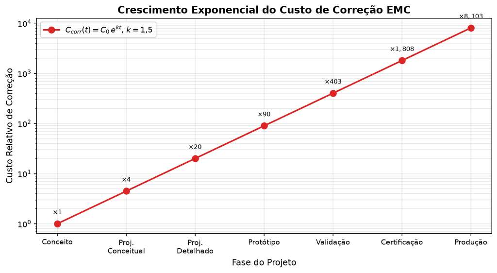

### 1.7.3 Curva de Otimização de Investimento EMC

PYTHON

```
import numpy as np
import matplotlib.pyplot as plt

# Parâmetros do modelo
N = 10000       # unidades
c_f = 50000     # custo por falha (USD)
p_0 = 0.10      # probabilidade base de falha
beta = 0.05     # eficácia (por USD*k)
P_base = 500000 # custo base do projeto (USD)
alpha = 0.08    # fator de acréscimo EMC
C_test_base = 25000  # custo base de teste (USD)

# Faixa de investimento EMC
E = np.linspace(10, 400, 500)  # USD*k

# Componentes de custo
C_design = alpha * P_base * (E / 200)  # proporcional ao investimento
C_test = C_test_base * (E / 200)
C_failure = N * c_f * p_0 * np.exp(-beta * E)
C_total = C_design + C_test + C_failure

# Encontrar ótimo
E_opt = E[np.argmin(C_total)]
C_min = C_total.min()

fig, ax = plt.subplots(figsize=(9, 5))
ax.plot(E, C_design, label="$C_{design}$", color="#3b82f6", linewidth=1.5)
ax.plot(E, C_test, label="$C_{test}$", color="#10b981", linewidth=1.5, linestyle="--")
ax.plot(E, C_failure, label="$C_{failure}$", color="#f59e0b", linewidth=1.5, linestyle="--")
ax.plot(E, C_total, "k-", linewidth=2.5, label="$C_{total}$")

ax.axvline(E_opt, color="#dc2626", linestyle=":", label=f"Ótimo: ${E_opt:,.0f}$k")
ax.axhline(C_min, color="#dc2626", linestyle=":", alpha=0.5)
ax.plot(E_opt, C_min, "r*", markersize=15, label=f"VPL mínimo: ${C_min:,.0f}")

ax.set_xlabel("Investimento em EMC (USD k)", fontsize=11)
ax.set_ylabel("Custo (USD)", fontsize=11)
ax.set_title("Curva de Otimização de Investimento EMC", fontsize=13, weight="bold")
ax.set_xlim(0, 400)
ax.legend(fontsize=9, loc="upper right")
ax.grid(True, alpha=0.3)

plt.tight_layout()
```

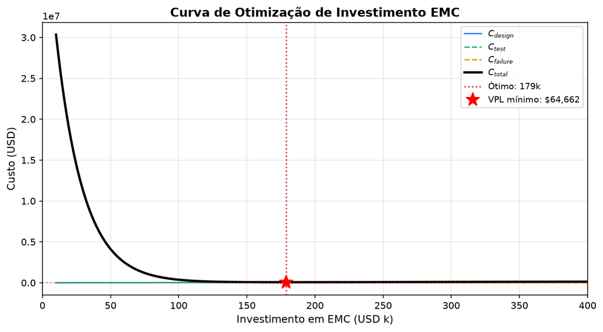

### 1.7.4 Análise Comparativa de ROI para Diferentes Estratégias

PYTHON

```
import numpy as np
import matplotlib.pyplot as plt

# Estratégias EMC
estrategias = {
    "Reativo\n(sem EMC)": {"alpha": 0.02, "beta": 0.02, "investimento": 50},
    "Padrão\n(indústria)": {"alpha": 0.08, "beta": 0.08, "investimento": 200},
    "Rigoroso\n(médico/automotivo)": {"alpha": 0.15, "beta": 0.15, "investimento": 400},
    "Excelência\n(aeroespacial)": {"alpha": 0.25, "beta": 0.20, "investimento": 800},
}

N = 10000
c_f = 50000
p_0 = 0.10
P_base = 500000
C_test = 25000

nome_list = list(estrategias.keys())
roi_list = []
custo_total_list = []

for nome, params in estrategias.items():
    E = params["investimento"]  # USD*k
    alpha = params["alpha"]
    beta = params["beta"]

    C_design = alpha * P_base
    C_total = C_design + C_test + N * c_f * p_0 * np.exp(-beta * E)
    C_sem_emc = 0 + C_test + N * c_f * p_0  # investimento zero em design EMC

    roi = ((C_sem_emc - C_total) / C_design) * 100 if C_design > 0 else np.nan
    roi_list.append(roi)
    custo_total_list.append(C_total)

fig, (ax1, ax2) = plt.subplots(1, 2, figsize=(14, 5))

# ROI por estratégia
bars = ax1.bar(nome_list, roi_list, color=["#3b82f6", "#10b981", "#f59e0b", "#dc2626"])
ax1.set_ylabel("ROI (%)", fontsize=11)
ax1.set_title("ROI por Estratégia EMC", fontsize=13, weight="bold")
ax1.axhline(0, color="black", linewidth=0.8)
ax1.tick_params(axis="x", labelsize=8)
for bar, val in zip(bars, roi_list):
    ax1.text(bar.get_x() + bar.get_width()/2, bar.get_height() + 200,
             f"{val:,.0f}%", ha="center", fontsize=9)

# Custo total por estratégia
bars2 = ax2.bar(nome_list, custo_total_list, color=["#3b82f6", "#10b981", "#f59e0b", "#dc2626"])
ax2.set_ylabel("Custo Total (USD)", fontsize=11)
ax2.set_title("Custo Total por Estratégia EMC", fontsize=13, weight="bold")
ax2.tick_params(axis="x", labelsize=8)
for bar, val in zip(bars2, custo_total_list):
    ax2.text(bar.get_x() + bar.get_width()/2, bar.get_height() + 50000,
             f"${val:,.0f}", ha="center", fontsize=8)

plt.tight_layout()
```

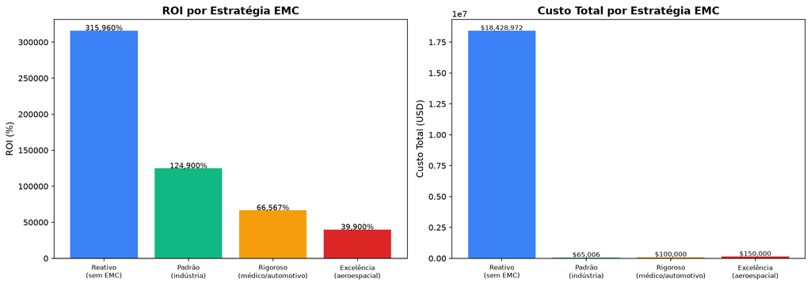

## 1.8 Lista de Exercícios Propostos

### 1.8.1 Problemas Teóricos

**E.1** Demonstre que a razão de crescimento exponencial $R(t) = e^{kt}$ implica que, se um problema de EMC é descoberto duas fases depois do ponto ideal, o custo de correção é pelo menos $e^{2k}$ vezes maior. Para $k=1{,}5$, calcule numericamente esse fator.

**E.2** Mostre que o valor presente de uma multa futura $M$ aplicada após $n$ anos, com taxa de desconto $r$, é $PV = M/(1+r)^n$. Calcule o VP de uma multa de 1 milhão de USD aplicada em $n=3$ anos, com $r=8\%$.

**E.3** Para $E\ge0$, mostre que $C(E)=aE+b+ce^{-\beta E}$ é estritamente convexa. Determine quando o mínimo é interior e quando ocorre na fronteira $E=0$.

**E.4** Para uma blindagem de parede plana de espessura $t$, mostre que a componente de absorção pode ser escrita como $A = 8{,}686 \cdot (t/\delta)$ dB, onde $\delta = \sqrt{2/(\omega\mu\sigma)}$. Calcule $A$ para uma chapa de cobre ($\sigma = 5{,}8\times10^7\ \text{S/m}$) de 0,5 mm a 1 GHz.

**E.5** Se um produto será vendido em 4 regiões com limites de emissão conduzida de 40, 30, 35 e 38 dBµV, determine o limite efetivo e a margem adicional (em dB) que o projeto deve fornecer em relação ao limite da região mais permissiva.

### 1.8.2 Problemas Numéricos

**E.6** Em milhares de USD, modele $C(E)=E+15+100000e^{-0{,}08E}$, $E\ge0$. Calcule o investimento ótimo, o custo esperado mínimo e o ROI incremental $[B(E)-E]/E$, onde $B(E)=100000(1-e^{-0{,}08E})$. Depois explique por que o resultado depende criticamente do modelo de perda de 100 milhões USD.

(a) O investimento ótimo $E^{*}$ em EMC (minimizando $C_{\text{total}}$).

(b) O custo total mínimo.

(c) O ROI nessa configuração.

**E.7** Um veículo elétrico ($N = 120.000$ unidades) apresenta falha de EMC em campo com probabilidade $p_f = 0{,}015$. Custo unitário de recall: 800 USD. Custo de reputação: 5 milhões de USD. Multa regulatória: 500.000 USD. Qual foi o custo total do incidente? Se o custo preventivo tivesse sido 100.000 USD, qual seria a razão custo-corretivo/custo-preventivo?

**E.8** Um custo de recall é incerto: probabilidade $p\in[0{,}5\%,2\%]$, 120.000 unidades, custo unitário triangular (500, 800, 1.500 USD) e custo fixo de 5,5 milhões USD se houver campanha. Formule o custo esperado condicionado ao cenário e indique como uma simulação Monte Carlo deve amostrar sem confundir probabilidade de cada unidade com probabilidade de uma campanha sistêmica.

**E.9** Uma empresa pode comprar módulo por 15 USD/unidade ou desenvolver: 80.000 USD de desenvolvimento, 25.000 USD de certificação e 2 USD/unidade de fabricação/integração. Para 30.000 unidades, compare custos e calcule o volume de equilíbrio. Liste custos/riscos omitidos antes de recomendar.

**E.10** Um dispositivo médico deve ser certificado na EUA (FCC), Europa (CE), Japão (VCCI) e China (CCC). Custos de certificação: 30.000, 40.000, 20.000 e 35.000 USD, respectivamente. Prazos: 6, 10, 5 e 8 semanas. Se o lançamento é simultâneo em todas as regiões, qual é o prazo mínimo de certificação? Qual é o custo total? Se as certificações forem feitas em paralelo, qual o ganho de tempo?

## 1.9 Gabarito

### 1.9.1 Soluções dos Problemas Teóricos

**E.1** $R(t) = e^{kt}$. Para $t = 2$ fases de atraso:

$$ R(2) = e^{k \cdot 2} = e^{2k} $$

Para $k = 1{,}5$: $e^{2 \times 1{,}5} = e^3 \approx \boxed{20{,}09}$

**E.2** $PV = M/(1+r)^n = 1.000.000/(1{,}08)^3 = 1.000.000/1{,}25971 \approx \boxed{793.832\ \text{USD}}$

**E.3** $C'=a-c\beta e^{-\beta E}$ e $C''=c\beta^2e^{-\beta E}>0$, logo há um único mínimo no domínio convexo. Se $c\beta>a$, o ponto interior é $E^*=\beta^{-1}\ln(c\beta/a)>0$. Se $c\beta\le a$, $C'(0)\ge0$ e o mínimo restrito é $\boxed{E^*=0}$. A versão anterior omitia essa condição de fronteira.

**E.4** $\delta=\sqrt{2/(\omega\mu_0\sigma)}\approx2{,}09\,\mu\text{m}$. Com $t=0{,}5\,\text{mm}$, $t/\delta\approx239$ e $A=8{,}686t/\delta\approx\boxed{2{,}08\times10^3\,\text{dB}}$ para folha homogênea ideal. Esse número excede a utilidade prática do modelo e a faixa dinâmica de ensaio; não significa gabinete perfeito, pois aberturas, juntas, cabos e contatos dominarão.

**E.5** Limite efetivo = $\min(40,\,30,\,35,\,38) = \boxed{30\ \text{dB}\mu\text{V}}$. Margem adicional em relação ao mais permissivo (40 dB): $40 - 30 = \boxed{10\ \text{dB}}$.

### 1.9.2 Soluções dos Problemas Numéricos

**E.6** $C'(E)=1-8000e^{-0{,}08E}=0$, logo  
$E^*=\ln(8000)/0{,}08\approx\boxed{112{,}34}$ mil USD. Nesse ponto, a perda residual é $100000/8000=12{,}5$ mil USD e  
$C(E^*)=112{,}34+15+12{,}5\approx\boxed{139{,}84}$ mil USD.

O benefício esperado é $B\approx100000-12{,}5=99987{,}5$ mil USD. Assim, o ROI incremental definido no enunciado é $(99987{,}5-112{,}34)/112{,}34\times100\%\approx\boxed{88\,900\%}$. O valor extremo não é previsão: nasce da hipótese de perda-base de 100 milhões USD e da exponencial calibrada arbitrariamente. Varie perda, $\beta$ e dependência entre falhas antes de decidir.

**E.7** $C_{\text{recall}} = 120.000 \times 0{,}015 \times 800 = 1.440.000\ \text{USD}$

$C_{\text{total}} = 1.440.000 + 5.000.000 + 500.000 = \boxed{6.940.000\ \text{USD}}$

Razão = $6.940.000 / 100.000 = \boxed{69{,}4\times}$

**E.8** Condicionado a uma taxa unitária $p$ e custo unitário $C_u$, o componente variável é $120000pC_u$; se a campanha ocorrer, some 5,5 milhões USD. Em Monte Carlo, amostre $p$ no intervalo segundo distribuição justificada e $C_u\sim\mathrm{Triangular}(500,800,1500)$. Modele separadamente o evento sistêmico da campanha: uma única causa comum não corresponde a 120.000 Bernoullis independentes. Reporte média, mediana, percentis e sensibilidade às dependências.

**E.9** $C_{\rm buy}=15(30000)=\boxed{450000}$ USD. $C_{\rm build}=80000+25000+2(30000)=\boxed{165000}$ USD. O equilíbrio resolve $15x=105000+2x$, portanto $x\approx\boxed{8077}$ unidades. No modelo fornecido, desenvolver custa menos a 30.000 unidades. Antes de recomendar, inclua integração do módulo comprado, BOM completa interna, royalties, manutenção, recertificação do produto final, prazo, risco técnico, rendimento, suporte e valor da flexibilidade; módulo certificado não transfere automaticamente conformidade ao produto.

**E.10** Prazo mínimo (lançamento simultâneo): todas as certificações devem estar concluídas. Se feitas sequencialmente: $6 + 10 + 5 + 8 = \boxed{29\ \text{semanas}}$.

Se feitas em paralelo (recursos permitem): $\max(6,\,10,\,5,\,8) = \boxed{10\ \text{semanas}}$.

Custo total: $30.000 + 40.000 + 20.000 + 35.000 = \boxed{125.000\ \text{USD}}$ (igual em ambos os casos).

Ganho de tempo com paralelismo: $29 - 10 = \boxed{19\ \text{semanas}} \approx 4{,}5\ \text{meses}$.

# 2. Caracterização e diagnóstico de casos EMC

> Este capítulo ensina a transformar um sintoma em um problema testável. Ele apresenta o modelo fonte–caminho–vítima e encaminha as derivações aos capítulos especializados, evitando repetir teoria de linhas, antenas, crosstalk, blindagem e projeto de sistemas.

## 2.1 Objetivos de aprendizagem

Ao final, você deve ser capaz de:

1. definir o sintoma e o critério de falha sem ambiguidade;
2. descrever fonte, caminho e vítima por grandezas mensuráveis;
3. distinguir acoplamento conduzido, capacitivo, indutivo e radiado;
4. separar modo diferencial (DM), modo comum (CM) e conversão de modo;
5. propor hipóteses concorrentes e uma medição que as discrimine;
6. demonstrar causalidade por previsão, intervenção e repetição;
7. registrar margem, incerteza e limites do diagnóstico.

## 2.2 O problema EMC como sistema

Uma interferência exige simultaneamente três elementos:

$$ \boxed{\text{fonte}\longrightarrow\text{caminho de acoplamento}\longrightarrow\text{vítima}} $$

- **Fonte:** produz energia indesejada na banda relevante.
- **Caminho:** transporta ou converte essa energia.
- **Vítima:** responde à perturbação e apresenta degradação funcional.

Mitigar qualquer elemento pode resolver o caso, mas isso não significa que interromper o caminho seja sempre a melhor solução. A decisão depende de eficácia, custo, segurança, robustez e possibilidade de alterar cada elemento.

Para um sistema aproximadamente linear e invariante no tempo,

$$ Y(f)=S(f)H_c(f)H_v(f), $$

em que $S(f)$ descreve a fonte, $H_c(f)$ o caminho e $H_v(f)$ a resposta da vítima. Em transientes, não linearidades ou saturação, esse produto é apenas um modelo inicial: é preciso trabalhar no tempo e incluir os estados do equipamento.

### 2.2.1 Correlação não é causalidade

Um pico no espectro na frequência do clock é uma pista, não uma prova. Uma conclusão forte combina:

1. **previsão:** a hipótese antecipa frequência, polarização, dependência geométrica ou estado operacional;
2. **intervenção:** uma mudança seletiva no elemento previsto altera o sintoma;
3. **repetição:** o efeito reaparece ao restaurar a condição original;
4. **controle:** configuração, cabos, instrumentos e software permanecem comparáveis.

## 2.3 Ficha mínima de caracterização

Antes de escolher filtros ou blindagem, preencha a ficha. Campos desconhecidos tornam-se itens de medição, não palpites.

| Elemento | O que registrar | Grandezas típicas |
| --- | --- | --- |
| Sintoma | função afetada, severidade, duração, taxa de ocorrência | erro, reset, BER, desvio, critério A/B/C |
| Estado | modos da fonte e da vítima, carga, firmware, cabos | tensão, corrente, potência, tráfego, temperatura |
| Fonte | forma de onda, repetição, bordas, espectro, impedância | $V$, $I$, $dv/dt$, $di/dt$, $f$, $t_r$, $Z_s(f)$ |
| Caminho | condutores, retornos, parasitas, distância, orientação | $Z(f)$, $C_m$, $M$, função de transferência |
| Vítima | porta de entrada, banda, limiar e modo de falha | $Z_{in}(f)$, ganho, limiar, janela temporal |
| Evidência | instrumento, detector, banda e geometria | RBW/VBW, tempo de aquisição, posição, incerteza |
| Margem | diferença entre perturbação e limite | dB, V, A, V/m, A/m |

Uma boa descrição é operacional: “o ADC excede 5 LSB em 18% das conversões quando o buck entra em *burst mode*” é melhor que “o sensor fica ruidoso”.

## 2.4 Caracterização da fonte

### 2.4.1 Domínio do tempo

Registre amplitude, duração, repetição, *duty cycle*, tempo de subida e simultaneidade com o sintoma. Bordas rápidas, não apenas a frequência fundamental, definem a banda excitada. Como estimativa de ordem de grandeza,

$$ f_{\text{knee}}\approx\frac{0{,}35}{t_r}, $$

desde que se declare a convenção usada para $t_r$ e para a largura de banda. O capítulo Fontes de ruído desenvolve fontes naturais, chaveamento, arcos e transmissores; Componentes não ideais explica como parasitas modificam as bordas.

### 2.4.2 Domínio da frequência

Em fontes periódicas, procure fundamental, harmônicos, bandas laterais e modulação pelo estado de carga. Em ruído aleatório ou transientes, registre densidade espectral, distribuição temporal e condições de disparo. Não compare diretamente pico temporal, valor RMS, espectro por bin e leitura de detector quase-pico: são grandezas diferentes.

### 2.4.3 Impedância e modo

A mesma tensão de circuito aberto pode injetar correntes muito diferentes. Caracterize $Z_s(f)$ e o retorno. Para dois condutores, adotando uma convenção simétrica,

$$ I_{CM}=\frac{I_1+I_2}{2},\qquad I_{DM}=\frac{I_1-I_2}{2}, $$

$$ I_1=I_{CM}+I_{DM},\qquad I_2=I_{CM}-I_{DM}. $$

O fator $1/2$ é uma convenção e deve ser mantido em todo o cálculo. Assimetrias convertem DM em CM; cabos podem então irradiar mesmo que o ruído tenha começado como diferencial. A decomposição e a medição são tratadas em Emissões conduzidas e Emissões radiadas.

## 2.5 Caracterização do caminho

Mais de um caminho pode coexistir. A classificação indica qual variável alterar primeiro.

| Mecanismo | Modelo inicial | Evidência que favorece a hipótese | Intervenção discriminante |
| --- | --- | --- | --- |
| impedância comum | $V_n=I_sZ_{comum}$ | sintoma acompanha corrente de carga | separar ou reduzir o retorno comum |
| capacitivo | $I_c=C_m\,dv/dt$ | forte efeito de proximidade e impedância da vítima | reduzir $dv/dt$, $C_m$ ou $Z_{in}$ |
| indutivo | $V_m=M\,di/dt$ | efeito de área/orientação dos loops | reduzir loop, $di/dt$ ou $M$ |
| linha de transmissão | reflexões por descontinuidade de $Z_0$ | efeito de comprimento e terminação | terminar ou alterar comprimento controladamente |
| radiado | antena emissora + propagação + antena receptora | efeito de distância, polarização e cabo | reduzir corrente CM ou eficiência da antena |
| conversão de modo | desbalanceamento DM $\leftrightarrow$ CM | assimetria em filtro, conector ou retorno | restaurar simetria e medir os dois modos |

Os modelos completos pertencem a:

- Linhas de transmissão: propagação, reflexões e terminações;
- Antenas: campos, ganho, abertura e regiões de campo;
- Crosstalk: acoplamentos capacitivo e indutivo, NEXT e FEXT;
- Blindagem: reflexão, absorção, aberturas, cabos e conectores.

### 2.5.1 Campo próximo e campo distante

$r\approx\lambda/(2\pi)$ é uma referência útil para a transição entre termos reativos e radiativos de uma fonte pequena, não uma fronteira universal. Para uma antena de maior dimensão $D$, a condição de campo distante também depende de $2D^2/\lambda$. Registre frequência, maior dimensão, distância e natureza da fonte antes de aplicar relações de onda plana.

## 2.6 Caracterização da vítima

A vítima não é apenas “o equipamento”. Localize a porta física e a etapa funcional em que a energia indesejada se torna erro.

### 2.6.1 Curva de suscetibilidade

Meça ou estime o limiar de falha em função de frequência, amplitude, modulação, polarização, porta e estado operacional. Uma única amplitude de ensaio não descreve a vítima inteira. Ressonâncias, proteção não linear, filtros e janelas de amostragem podem produzir regiões estreitas de alta suscetibilidade.

Para uma exigência $A_{req}$ e um limiar de falha $A_{fail}$, ambos na mesma grandeza e condição,

$$ M_{imunidade}=20\log_{10}\!\left(\frac{A_{fail}}{A_{req}}\right). $$

Margem positiva indica que o limiar está acima do nível requerido. Inclua incerteza e variabilidade; uma margem nominal pequena não demonstra robustez.

### 2.6.2 Critério funcional

Defina antes do ensaio se são aceitáveis degradação temporária, autorrecuperação ou perda de dados. Os critérios e níveis vêm da norma de produto e do plano de ensaio aplicáveis; veja Normas e ensaios. Não transforme um exemplo didático em limite regulatório.

## 2.7 Método de diagnóstico em sete passos

### 2.7.1 Passo 1 — Tornar o sintoma reproduzível

Fixe configuração, cabos, carga, software, temperatura e sequência. Registre taxa-base e critério objetivo.

### 2.7.2 Passo 2 — Construir a linha do tempo

Correlacione evento da fonte, grandeza acoplada e falha. Use disparo comum quando possível. Cuidado com atrasos de firmware e mecanismos de proteção.

### 2.7.3 Passo 3 — Formular hipóteses concorrentes

Cada hipótese deve nomear fonte, caminho, porta da vítima e uma previsão exclusiva. Exemplo: “corrente CM do buck retorna pela blindagem do cabo e entra no ADC pelo conector” é testável; “é EMI” não é.

### 2.7.4 Passo 4 — Ordenar por evidência e custo

Priorize hipóteses que explicam mais observações e que possam ser testadas com alteração reversível e segura.

### 2.7.5 Passo 5 — Medir sem perturbar excessivamente

Declare largura de banda, carga da ponta, piso de ruído, detector e posição. Uma ponta longa de osciloscópio ou uma sonda de campo próxima demais pode criar o resultado que se pretendia observar.

### 2.7.6 Passo 6 — Alterar uma variável por vez

Exemplos: ferrite temporário no cabo, terminação controlada, redução de *slew rate*, placa metálica provisória, rotação de loop ou alimentação isolada. A intervenção deve selecionar um mecanismo, não apenas “melhorar tudo”.

### 2.7.7 Passo 7 — Confirmar e documentar margem

Restaure a condição original, reproduza a falha, aplique novamente a correção e repita em unidades e estados representativos. Registre antes/depois, incerteza, efeitos colaterais e margem.

### 2.7.8 Matriz de hipóteses

| Hipótese | Predição | Medição | Confirma se | Refuta se |
| --- | --- | --- | --- | --- |
| ripple DM na entrada | pico acompanha $f_{sw}$ nas duas linhas em oposição | LISN ou duas sondas de corrente | componente DM acompanha o sintoma | só CM muda |
| cabo como antena CM | emissão muda com posição/comprimento | clamp de corrente + variação geométrica | campo e $I_{CM}$ variam juntos | $I_{CM}$ permanece no piso |
| crosstalk local | erro cresce com $dv/dt$, $di/dt$ e paralelismo | sonda local + alteração de borda | resposta segue geometria/borda | alteração seletiva não tem efeito |
| descontinuidade de retorno | problema coincide com troca de plano/via | TDR ou inspeção de retorno | stitching próximo reduz conversão | caminho de retorno já é contínuo |
| ressonância da PDN | erro coincide com pico de $\|Z_{PDN}\|$ | VNA/injeção de impedância | amortecimento desloca/reduz ambos | pico e falha não se correlacionam |

## 2.8 Casos integradores

### 2.8.1 Buck interfere em sensor analógico

**Sintoma:** erro do ADC aparece apenas sob carga leve.

**Hipóteses:** ripple DM pela alimentação; corrente CM pelo acoplamento do nó de comutação; acoplamento local do loop quente ao sinal.

**Teste discriminante:** medir simultaneamente o nó de comutação, a alimentação do sensor e o erro; decompor a corrente no cabo em CM/DM; variar *slew rate* sem mudar $f_{sw}$; aproximar uma sonda magnética do loop quente.

**Encaminhamento:** fonte no cap. 3, componentes e parasitas no cap. 6, condução no cap. 10 e projeto sistêmico no cap. 16.

### 2.8.2 Clock digital causa emissão em cabo

**Sintoma:** pico radiado em harmônico do clock muda quando o cabo é movido.

**Hipótese principal:** descontinuidade de retorno converte corrente DM em CM; o cabo é a antena eficiente.

**Teste discriminante:** medir corrente CM no cabo; reduzir temporariamente o *slew rate*; acrescentar conexão de chassi de baixa indutância no conector; comparar polarização e posição.

**Armadilha:** blindar apenas a trilha do clock pode não alterar a corrente de modo comum que efetivamente irradia.

### 2.8.3 ESD na carcaça reinicia o equipamento

**Sintoma:** reset durante descarga, sem dano permanente.

**Hipóteses:** corrente pela referência lógica; acoplamento por abertura; disparo de pino de reset; queda da PDN.

**Teste discriminante:** monitorar pino de reset e alimentação com técnica apropriada; mapear corrente na carcaça; variar o ponto de descarga e o fechamento das juntas; injetar perturbação controlada nas portas suspeitas.

**Segurança:** ensaios de ESD exigem arranjo, gerador, calibração e proteção definidos. Consulte o cap. 4 e modele transientes conforme o cap. 13.

### 2.8.4 Reflexão confundida com crosstalk

**Sintoma:** overshoot em uma entrada digital após mudança de comprimento da trilha.

**Hipóteses:** reflexão por desadaptação; crosstalk de uma linha vizinha; *ground bounce* no encapsulamento.

**Teste discriminante:** observar dependência com comprimento e terminação; silenciar a linha agressora; medir referência local da vítima. Use o cap. 7 para reflexões e o cap. 9 para acoplamento entre linhas.

## 2.9 Escolha da mitigação

Depois de identificar o mecanismo, escolha a intervenção mais próxima da causa e verifique efeitos colaterais.

| Atuação | Exemplos | Possíveis custos |
| --- | --- | --- |
| fonte | reduzir borda, loop quente, amplitude ou corrente CM | dissipação, temporização, eficiência |
| caminho | controlar retorno, separar, filtrar, terminar, blindar | área, peso, ressonância, corrente de fuga |
| vítima | filtrar porta, aumentar histerese, proteger, corrigir software | latência, banda, capacitância, mascaramento de falha |

As técnicas são reunidas em Minimização de interferências, detalhadas em Projeto de PCBs e integradas em Projeto de sistemas. A implementação e a simulação prática aparecem em KiCad.

## 2.10 Exercícios de consolidação

**E.1** Um conversor de 500 kHz causa erro em um termopar somente quando o cabo passa perto do indutor. Escreva três hipóteses completas e uma medição discriminante para cada uma.

**E.2** Duas correntes medidas são $I_1=32\,\text{mA}$ e $I_2=-28\,\text{mA}$. Calcule $I_{CM}$ e $I_{DM}$ pela convenção deste capítulo e reconstrua $I_1$ e $I_2$.

**E.3** Um equipamento falha a $3\,\text{V/m}$ e deve operar a $10\,\text{V/m}$. Calcule a margem nominal e explique por que o valor sozinho não encerra a avaliação.

**E.4** Liste as evidências que distinguem reflexão, crosstalk e *ground bounce* em um sinal digital com overshoot.

**E.5** Construa uma ficha de caracterização para um reset durante ESD, marcando como “desconhecido” tudo que exigiria medição.

**E.6** Explique por que multiplicar o pico temporal de corrente ESD por uma impedância conhecida apenas em 100 MHz não determina a tensão transitória na vítima.

**E.7** Um pico radiado diminui 12 dB com ferrite no cabo, mas a corrente DM não muda. Qual hipótese ganhou força? Que repetição ou controle ainda é necessário?

### 2.10.1 Respostas orientativas

**E.2** $I_{CM}=2\,\text{mA}$ e $I_{DM}=30\,\text{mA}$; portanto $I_1=2+30=32\,\text{mA}$ e $I_2=2-30=-28\,\text{mA}$.

**E.3** $20\log_{10}(3/10)=-10{,}46\,\text{dB}$. A margem é negativa; ainda se devem declarar modulação, banda, polarização, critério funcional, incerteza e estado operacional.

**E.6** Pico temporal e impedância fasorial monofrequencial pertencem a descrições diferentes. É necessário obter $I(f)$ e $Z(f)$ na banda relevante e calcular $v(t)=\mathcal{F}^{-1}\{I(f)Z(f)\}$, incluindo não linearidades e a resposta da vítima.

**E.7** Ganha força a hipótese de emissão por corrente CM no cabo. É preciso medir $I_{CM}$ antes/depois, restaurar a condição original, repetir a intervenção e controlar posição do cabo, estado do equipamento e configuração de medição.

## 2.11 Laboratório — pontuação de hipóteses

Pontuação não prova causalidade, mas torna explícita a atualização das hipóteses. Use pesos definidos antes do teste e preserve resultados que contradigam a hipótese favorita.

PYTHON

```
import numpy as np
hypotheses = ['DM pela alimentação', 'CM pelo cabo', 'crosstalk local']
tests = ['muda com LISN/filtro DM', 'muda com ferrite no cabo',
         'muda com orientação/sonda local']
# linhas: hipóteses; colunas: previsão de resposta (0 a 1)
prediction = np.array([[.9, .2, .3], [.2, .9, .5], [.2, .3, .9]])
observed = np.array([.1, .9, .7])
error = np.sum((prediction-observed)**2, axis=1)
score = np.exp(-error)
score /= score.sum()
for h, s in sorted(zip(hypotheses, score), key=lambda x: -x[1]):
    print(f'{h:24s}: {s:.3f}')
```

**Output:**

```
CM pelo cabo            : 0.503
crosstalk local         : 0.351
DM pela alimentação     : 0.146
```

Repita com outros pesos e inclua uma hipótese “mecanismo não modelado”. A etapa decisiva continua sendo intervenção seletiva, restauração e repetição.

## 2.12 Entrega recomendada: relatório de diagnóstico

Um relatório curto e auditável deve conter:

1. sintoma, critério de falha e configuração;
2. diagrama fonte–caminho–vítima;
3. hipóteses e previsões;
4. instrumentos, banda, detector, geometria e incerteza;
5. resultados antes/depois;
6. hipótese confirmada e alternativas ainda abertas;
7. correção, efeitos colaterais e margem;
8. condições para repetir o ensaio.

Esse relatório é a ponte entre a caracterização introdutória, os mecanismos dos capítulos 6–12 e a síntese dos capítulos 13–16. Ele evita duas falhas comuns: aplicar uma solução por hábito e confundir melhora ocasional com compreensão do mecanismo.

# 3. Fontes de Ruído Eletromagnético — Natural, Industrial e Artificial

> Compatibilidade Eletromagnética — Apostila de Curso  
> Tópicos: Classificação de fontes · Ruído natural (atmosférico, cósmico, térmico) · Ruído industrial (chaveamento, arcos) · Telecomunicações · Dispositivos domésticos · CISPR e limites · Análises em Python

## 3.1 Antes de começar

Ao final, você deve classificar fontes por origem, espectro, repetitividade, modo e impedância, relacionando $dV/dt$ e $dI/dt$ aos caminhos de acoplamento. **Diagnóstico:** a frequência de chaveamento é necessariamente a maior frequência relevante para EMC? **Evidência mínima:** prever harmônicos a partir do tempo de subida e confrontar a previsão com uma FFT corretamente escalada.

## 3.2 Classificação das Fontes de Ruído Eletromagnético

A **compatibilidade eletromagnética** (EMC) exige que todo equipamento eletrônico opere em um ambiente eletromagnético sem sofrer degradação e sem emitir interferências além dos limites estabelecidos por normas. O primeiro passo para qualquer análise de EMC é identificar e classificar as **fontes de ruído** presentes no ambiente.

### 3.2.1 Fontes Naturais vs. Artificiais

Toda fonte de interferência eletromagnética (EMI) pertence a uma das duas categorias fundamentais:

| Categoria | Origem | Exemplos |
| --- | --- | --- |
| **Natural** | Fenômenos da natureza | Relâmpagos, radiação cósmica, ruído térmico, auroras |
| **Artificial** | Equipamentos e sistemas fabricados | Conversores DC-DC, transmissores, motores, computadores |

**Observação:** A distinção é importante porque as estratégias de mitigação são radicalmente diferentes. Fontes naturais são incontroláveis — a mitigação é feita por projeto do receptor (blindagem, filtragem, redução de ganho). Fontes artificiais podem ser controladas na origem (projeto do emissor, blindagem da fonte, filtragem de emissão).

### 3.2.2 Espectro de Interferências no Ambiente RF

O espectro eletromagnético de interferências varia enormemente em frequência, potência e temporalidade. A figura conceitual a seguir esquematiza as principais regiões:

```
Frequência (Hz)    Fonte Dominante
──────────────────────────────────────────────────────
   0 – 10 kHz      Ruído galáctico + descargas atmosféricas
  10 kHz – 1 MHz   Ruído atmosférico intenso + ruído industrial
   1 – 30 MHz      Transmissores AM + ruído industrial + atmosférico residual
  30 – 300 MHz      Transmissores FM/TV + ruído térmico dominante
 300 MHz – 3 GHz    Telecomunicações (celular, Wi-Fi) + chaveamento digital
   3 – 30 GHz       Enlaces de micro-ondas + radar + ruído atmosférico
  30 GHz – 300 GHz   Absorção atmosférica (H₂O, O₂) + ruído térmico
```

### 3.2.3 Classificação por Natureza Temporal

Além da origem, as fontes são classificadas pela **natureza do sinal** que geram.

**Contínua vs. Impulsiva:**

$$ \boxed{ \begin{array}{ll} \text{Contínua (CW):} & s(t) = A\cos(2\pi f_0 t + \phi) \\ \text{Impulsiva:} & s(t) = \sum_{k} A_k \cdot p(t - t_k) \end{array} } $$

onde $p(t)$ é um pulso com duração finita e $t_k$ são instantes de ocorrência estocásticos.

**Narrowband vs. Broadband:**

Uma fonte é **narrowband** quando sua energia está concentrada em uma banda estreita $\Delta f \ll f_c$:

$$ \boxed{S_{\text{narrow}}(f) \approx P_0 \cdot \delta(f - f_c) * W(f)} $$

com $W(f)$ uma janela de largura $\Delta f$ centrada em $f_c$. Fontes narrowband típicas: transmissores de rádio, osciladores.

Uma fonte é **broadband** quando sua densidade espectral de potência (PSD) se estende sobre uma faixa ampla:

$$ \boxed{S_{\text{broad}}(f) \propto f^{-\alpha}, \quad \alpha > 0} $$

Fontes broadband típicas: descargas elétricas, chaveamento de cargas indutivas, ruído térmico.

**Definição:** Uma fonte de ruído é caracterizada por quatro parâmetros fundamentais: (i) faixa de frequência de emissão, (ii) potência/espectro, (iii) natureza temporal (contínua/impulsiva), e (iv) mecanismo de acoplamento (conduzido ou irradiado).

## 3.3 Fontes Naturais de Ruído

### 3.3.1 Ruído Atmosférico (Descargas Elétricas)

O ruído atmosférico é gerado por **relâmpagos** — descargas eletrostáticas entre nuvens e entre nuvens e o solo. Cada relâmpago gera um pulso de corrente com duração de alguns microssegundos e amplitude de dezenas a centenas de quilamperes.

O espectro médio do ruído atmosférico é modelado pela **fórmula de Robinson** (ITU-R P.372):

$$ \boxed{P_{\text{atmos}}(f) \propto \frac{1}{1 + \left(\dfrac{f}{f_c}\right)^2}} $$

O **índice de ruído atmosférico** $N$ em decibéis acima de $kTB$ (onde $k$ é a constante de Boltzmann, $T = 290\,\text{K}$, e $B$ é a largura de banda) é dado pela ITU-R P.372:

$$ N(f, \lambda) = A + B \cdot e^{-C(f-1)} + D(\lambda) \cdot e^{-E(f-1)} $$

onde $f$ está em GHz, $\lambda$ é a latitude geográfica, e $A$–$E$ são parâmetros empíricos tabelados.

### 3.3.2 Ruído Cósmico

A radiação cósmica de fundo e a radiação sincrotrão do Sol e de fontes extragalácticas contribuem para o ruído recebido por antenas orientadas para o céu. Para frequências abaixo de $\approx 1\,\text{GHz}$, a **temperatura de ruído do céu** é bem aproximada por:

$$ \boxed{T_{\text{sky}}(f) \approx 25\,000 \left(\frac{f}{1\,\text{MHz}}\right)^{-2.55}\,\text{K}} $$

Esta lei de potência descreve a emissão sincrotrão de elétrons relativísticos nos campos magnéticos galácticos. A dependência $f^{-2.55}$ é característica de espectros sincrotrón com distribuição de energia de elétrons $N(E) \propto E^{-p}$, onde $p \approx 2.7$.

Para $f = 100\,\text{MHz}$:

$$ T_{\text{sky}}(100\,\text{MHz}) \approx 25\,000 \cdot (10^8)^{-2.55} = 25\,000 \cdot 10^{-20.4} \approx 0{,}063\,\text{K} $$

Para $f = 10\,\text{MHz}$:

$$ T_{\text{sky}}(10\,\text{MHz}) \approx 25\,000 \cdot (10^7)^{-2.55} \approx 25\,000 \cdot 10^{-17.85} \approx 1\,330\,\text{K} $$

**Observação:** A temperatura de ruído efetiva vista por uma antena é:

$$ T_{\text{ant}} = \eta_{\text{ant}} T_{\text{sky}} + (1 - \eta_{\text{ant}}) T_{\text{ground}} $$

onde $\eta_{\text{ant}}$ é a eficiência de radiação e $T_{\text{ground}} \approx 290\,\text{K}$ é a temperatura física do solo. Para antenas com lóbulo principal baixo no horizonte, $T_{\text{ground}}$ domina.

### 3.3.3 Ruído Térmico de Johnson-Nyquist

Todo condutor em equilíbrio térmico gera uma **tensão de ruído** devido ao movimento térmico aleatório dos portadores de carga. Este é o **ruído de Johnson-Nyquist**, fundamental em toda análise de sensibilidade de receptores.

**Teorema de Johnson-Nyquist (regime clássico):** um resistor $R$ à temperatura absoluta $T$ apresenta, em circuito aberto, PSD unilateral de tensão aproximadamente constante:

$$ \boxed{S_{V}(f) = 4\,k_B\,T\,R \quad [\text{V}^2/\text{Hz}]} $$

onde $k_B = 1{,}381 \times 10^{-23}\,\text{J/K}$ é a constante de Boltzmann.

**Convenção:** aqui $S_V(f)$ é unilateral ($f\ge0$) e $B$ é a largura de banda equivalente de ruído. Na convenção bilateral, cada lado possui $2k_BTR$. A aproximação branca clássica requer $hf\ll k_BT$; não se integra $4k_BTR$ até frequência infinita.

A tensão RMS medida em uma banda $B$ é:

$$ \boxed{V_n = \sqrt{4\,k_B\,T\,R\,B}} $$

Da mesma forma, a potência de ruído disponível (potência máxima transferível para uma carga casada) é:

$$ \boxed{P_n = k_B\,T\,B} $$

Em decibéis em relação a 1 watt ($\text{dBW}$):

$$ P_n\,[\text{dBW}] = 10\log_{10}(k_B T B) $$

Para $T = 290\,\text{K}$ e $B = 1\,\text{Hz}$:

$$ k_B T = (1{,}381 \times 10^{-23})(290) \approx 4{,}005 \times 10^{-21}\,\text{W} $$

$$ k_B T\,[\text{dBW/Hz}] = 10\log_{10}(4{,}005 \times 10^{-21}) \approx -204\,\text{dBW/Hz} $$

Em unidades de $\text{dBm/Hz}$ ($1\,\text{mW} = 10^{-3}\,\text{W}$):

$$ k_B T\,[\text{dBm/Hz}] = -204 + 30 = \boxed{-174\,\text{dBm/Hz}} $$

**Este número — $-174\,\text{dBm/Hz}$ a $290\,\text{K}$ — é um dos mais importantes em telecomunicações.**

**Exemplo:** Calcule a tensão de ruído RMS de um resistor de $50\,\Omega$ a $T = 300\,\text{K}$ em uma banda de $B = 10\,\text{MHz}$:

$$ V_n = \sqrt{4 \cdot (1{,}381\times 10^{-23}) \cdot 300 \cdot 50 \cdot (10\times 10^6)} $$

$$ V_n = \sqrt{4 \cdot 1{,}381 \cdot 300 \cdot 50 \cdot 10^{-17}} = \sqrt{8{,}286 \times 10^{-13}} \approx 9{,}10 \times 10^{-7}\,\text{V} = 910\,\text{nV RMS} $$

### 3.3.4 Ruído de Fundo Cósmico (CMB)

O **Fundo Cósmico de Micro-ondas** (CMB — Cosmic Microwave Background) é a radiação eletromagnética remanescente do Big Bang, com espectro de corpo negro a $T_{\text{CMB}} \approx 2{,}725\,\text{K}$. Sua contribuição para o ruído de antena é significativa apenas em frequências acima de $\approx 5\,\text{GHz}$, onde o ruído cósmico sincrotrón já decaiu enormemente.

A densidade espectral de potência do CMB é dada pela **lei de Planck**:

$$ \boxed{B_{\nu}(T) = \frac{2h\nu^3}{c^2} \cdot \frac{1}{e^{h\nu/(k_B T)} - 1}} $$

No limite de baixas frequências ($h\nu \ll k_B T$), recupera-se a **lei de Rayleigh-Jeans**:

$$ B_{\nu}(T) \approx \frac{2\nu^2}{c^2} k_B T $$

### 3.3.5 Limite de Friis para Sensibilidade do Receptor

O piso de sensibilidade de um receptor é determinado pelo ruído referido à entrada e pelo critério de detecção. Não confunda a **equação de transmissão de Friis** (potência recebida em um enlace) com a **fórmula de Friis para ruído** (cascata de fatores de ruído); são resultados diferentes associados ao mesmo autor.

**Equação de sensibilidade:** a potência mínima detectável depende do ruído total referido à entrada e da SNR mínima exigida. Há duas formas equivalentes, desde que não sejam misturadas.

Se a fonte está na temperatura padrão $T_0=290\,\text{K}$ e o receptor tem fator de ruído $F$:

$$ \boxed{P_{\text{min}}=k_BT_0BF\,(SNR)_{\text{min}}} $$

Se a antena tem temperatura $T_{\text{ant}}$ e o receptor adiciona temperatura equivalente $T_e=(F-1)T_0$:

$$ \boxed{P_{\text{min}}=k_B(T_{\text{ant}}+T_e)B\,(SNR)_{\text{min}}} $$

onde $T_{\text{sys}}=T_{\text{ant}}+T_e$ (mais outras contribuições referidas ao mesmo plano). Portanto,

$$ \boxed{P_{\text{min}}=k_BT_{\text{sys}}B\,(SNR)_{\text{min}}}. $$

**Erro comum:** não multiplique $k_BT_{\text{sys}}B$ por $F$ se $T_{\text{sys}}$ já inclui $T_e$; isso contaria o ruído do receptor duas vezes.

Nas expressões:

- $T_{\text{sys}}$ é a temperatura de ruído total referida à entrada,
- $B$ é a largura de banda,
- $(SNR)_{\text{min}}$ é a relação sinal-ruído mínima necessária para detecção,
- $F$ é o **fator de ruído** do receptor (em linear).

O **fator de ruído** é definido como:

$$ \boxed{F \equiv \frac{(SNR)_{\text{in}}}{(SNR)_{\text{out}}} \geq 1} $$

Em decibéis:

$$ F_{\text{dB}} = 10\log_{10} F $$

Para um amplificador com ganho $G$ e fator de ruído $F$, a temperatura de ruído equivalente é:

$$ \boxed{T_e = (F - 1) T_0} $$

onde $T_0 = 290\,\text{K}$ é a temperatura de referência.

Para estágios em cascata, a **fórmula de Friis para fator de ruído** é:

$$ \boxed{F_{\text{total}} = F_1 + \frac{F_2 - 1}{G_1} + \frac{F_3 - 1}{G_1 G_2} + \cdots} $$

**Importante:** O primeiro estágio é dominante. Por isso, LNA (Low-Noise Amplifier) com baixo $F$ e alto $G$ é sempre o primeiro componente na cadeia de recepção.

Mais precisamente, o LNA deve aparecer cedo, depois das perdas passivas inevitáveis e da proteção necessária. Um filtro ou cabo antes dele adiciona sua perda ao orçamento e degrada a figura de ruído; “sempre o primeiro componente” não é uma regra física absoluta.

## 3.4 Fontes Industriais de Ruído — Chaveamento

### 3.4.1 Conversores DC-DC, Inversores e Drives de Motor

Fontes chaveadas são a **fonte de ruído industrial mais ubíqua**. Inversores, drives de motor, fontes chaveadas de alimentação e conversores DC-DC operam abrindo e fechando chaves eletrônicas (MOSFETs, IGBTs) a frequências de dezenas de kHz a dezenas de MHz.

O mecanismo fundamental de geração de ruído é o **chaveamento**: uma transição rápida entre dois estados gera harmônicos em larga faixa de frequência e correntes/transições de tensão elevadas.

### 3.4.2 Forma de Onda de Chaveamento e Harmônicos

Considere um conversor buck básico com onda quadrada de tensão. A tensão de saída é uma onda quadrada de amplitude $V_{dc}$ e período $T = 1/f_s$, com ciclo de serviço $D$:

$$ v(t) = \begin{cases} V_{dc}, & 0 \leq t < DT \\ 0, & DT \leq t < T \end{cases} $$

expandindo em série de Fourier:

$$ \boxed{v(t) = D V_{dc} + \sum_{n=1}^{\infty} \frac{2V_{dc}}{n\pi} \sin(n\pi D) \cos(n\omega_0 t)} $$

com $\omega_0 = 2\pi f_s$. Os harmônicos têm amplitudes:

$$ V_n = \frac{2V_{dc}}{n\pi} |\sin(n\pi D)| $$

Para onda quadrada simétrica ($D = 0{,}5$):

$$ \boxed{v(t) = \frac{V_{dc}}{2} + \sum_{k=0}^{\infty} \frac{4V_{dc}}{(2k+1)\pi} \sin((2k+1)\omega_0 t)} $$

Somente harmônicos ímpares. O $n$-ésimo harmônico decai com $1/n$ (ou $-20\,\text{dB}/\text{decada}$).

### 3.4.3 dV/dt e dI/dt como Mecanismos de Acoplamento

As transições rápidas de chaveamento geram altos valores de dV/dt e dI/dt, que são os **mecanismos primários de acoplamento de EMI**:

**Acoplamento capacitivo (via dV/dt):**

$$ \boxed{i_{\text{coupled}} = C_{\text{parasita}} \frac{dV}{dt}} $$

onde $C_{\text{parasita}}$ é a capacitância parasita entre a chave e o circuito sensível.

**Acoplamento indutivo (via dI/dt):**

$$ \boxed{v_{\text{coupled}} = M \frac{dI}{dt}} $$

onde $M$ é a indutância mútua parasita entre o laço de comutação e o circuito afetado.

**Exemplo:** Um MOSFET chaveando $400\,\text{V}$ em $t_r = 10\,\text{ns}$ com $C_p = 1\,\text{pF}$ gera:

$$ i_{\text{coupled}} = 10^{-12} \cdot \frac{400}{10 \times 10^{-9}} = 40\,\text{mA} $$

Esta corrente injetada em um circuito de medição de $1\,\text{k}\Omega$ gera $40\,\text{V}$ de interferência.

### 3.4.4 Frequência de Chaveamento e Espectro de EMI

O espectro de emissão de uma fonte chaveada possui três regiões distintas (modelagem de McCroskey):

1. **Região de harmônicos discretos** ($f < 1/(2\pi\tau_r)$): harmônicos da frequência de chaveamento com decaimento $-20\,\text{dB}/\text{decada}$
2. **Região de transição** ($f \approx 1/(2\pi\tau_r)$): pico de máxima emissão
3. **Região de decaimento rápido** ($f > 1/(2\pi\tau_r)$): decaimento $-40\,\text{dB}/\text{decada}$

onde $\tau_r$ é o tempo de subida da chave.

A **frequência de corte do espectro** é:

$$ \boxed{f_{\text{max}} \approx \frac{0{,}35}{\tau_r}} $$

Reduzir $\tau_r$ aumenta a largura de banda das emissões (piora EMI), mas aumentar $\tau_r$ aumenta as perdas de chaveamento ($P_{\text{sw}} \propto \tau_r$). Este é um **trade-off fundamental** do projeto EMC.

### 3.4.5 Mitigação de Ruído de Chaveamento

As técnicas principais são:

1. **Snubbers** (RC ou RCD) — reduzem dV/dt e dI/dt
2. **Filtros EMI** (LC, π, T) — atenuam emissões conduzidas
3. **Blindagem** — contêm emissões irradiadas
4. **Spread Spectrum Clocking** — espalham energia harmônica
5. **Layout otimizado** — minimizar laços de comutação e acoplamentos parasitas

## 3.5 Fontes Industriais — Arcos Elétricos e Solda

### 3.5.1 Ruído de Solda

Processos de solda (MIG, TIG, eletrodo revestido) geram ruído de banda larga através do **arco elétrico** — um plasma condutor com temperatura de $5\,000$ a $20\,000\,\text{K}$. O espectro do ruído de solda segue uma lei de potência:

$$ \boxed{S_{\text{weld}}(f) \propto f^{-\alpha}} $$

com $\alpha$ tipicamente entre $0{,}5$ e $2{,}0$, dependendo do tipo de solda e dos parâmetros de processo.

O arco de solda se comporta como um **gerador de corrente aleatória** com componentes em toda a faixa de RF. As emissões podem ser particularmente intensas entre $10\,\text{kHz}$ e $100\,\text{MHz}$.

**Definição:** Uma fonte de arco elétrico é modelada como um resistor não-linear variável no tempo:

$$ R_{\text{arc}}(t) = \frac{V_{\text{arc}}}{I_{\text{arc}}(t)} $$

com $V_{\text{arc}} \approx 20\text{--}50\,\text{V}$ e $I_{\text{arc}}$ com flutuações aleatórias de alta frequência.

### 3.5.2 Motores com Escovas

Motores DC com escovas de carbono geram EMI por **faiscamento** entre as escovas e o comutador. A cada comutação, há uma faísca transiente com espectro de banda larga:

$$ S_{\text{brush}}(f) \propto \frac{1}{f} \quad \text{(ruído tipo } 1/f \text{ adicional ao térmico)} $$

As faíscas são pulsos de duração $\tau \approx 1\text{--}10\,\text{ns}$, o que implica componentes espectrais até $f_{\text{max}} \approx 35\text{--}350\,\text{MHz}$.

### 3.5.3 Fornos a Arco

Fornos a arco (usados na siderurgia) são fontes de interferência de **altíssima potência**. Modelados como fontes de corrente impulsivas:

$$ \boxed{I_{\text{arc}}(t) = \sum_{k} I_k \cdot \exp\left(-\frac{(t - t_k)^2}{2\sigma^2}\right) \cos(2\pi f_c (t - t_k))} $$

onde $I_k$ é a amplitude do $k$-ésimo pulso, $\sigma$ controla a largura temporal e $f_c \approx 50\text{--}60\,\text{Hz}$ é a frequência da rede.

**Importante:** Fornecedores a arco podem injetar **correntes de sequência negativa** e harmônicas na rede elétrica, afetando todo o sistema de distribuição.

## 3.6 Telecomunicações e Transmissores

### 3.6.1 Transmissores de Rádio, TV e Celular

Transmissores de comunicação são fontes **intencionais** de ruído — eles emitem sinais, mas podem causar interferência não-intencional quando seus harmônicos, intermodulações ou emissões espúrias atingem frequências não autorizadas.

### 3.6.2 Potência Irradiada Efetiva (EIRP)

A **potência irradiada efetiva** é a potência aparente irradiada por um transmissor, incluindo o ganho da antena e as perdas do cabo:

$$ \boxed{EIRP = P_{\text{trans}} + G_{\text{ant}} - L_{\text{cable}}} $$

Todas as grandezas em $\text{dBW}$ (ou $\text{dBm}$). Em linear:

$$ EIRP_{\text{linear}} = P_{\text{trans}} \cdot G_{\text{ant}} \cdot L_{\text{cable}} $$

onde $P_{\text{trans}}$ é a potência do transmissor, $G_{\text{ant}}$ é o ganho da antena (linear, $>1$), e $L_{\text{cable}}$ é a perda do cabo (linear, $<1$).

**Exemplo:** Transmissor de $10\,\text{W}$ ($40\,\text{dBm}$), antena com ganho de $15\,\text{dBi}$, cabo com perda de $2\,\text{dB}$:

$$ EIRP = 40 + 15 - 2 = 53\,\text{dBm} = 200\,\text{W} $$

### 3.6.3 Interferência Co-Canal, Adjacente e Intermodulação

**Interferência co-canál:** Dois transmissores na mesma frequência ocupando a mesma área de cobertura. Causa colisão direta.

**Interferência adjacente:** Transmissor em frequência vizinha invade o canal do receptor devido à seletividade finita do filtro do receptor.

**Intermodulação:** Quando dois ou mais sinais de frequências $f_1$ e $f_2$ passam por um componente não-linear (amplificador, conector oxidado, etc.), são geradas frequências de intermodulação:

$$ \boxed{f_{IM3} = 2f_1 - f_2 \quad \text{e} \quad f_{IM3}' = 2f_2 - f_1} $$

Estas são as **intermodulações de terceira ordem**, as mais problemáticas pois caem próximas aos sinais originais e são difíceis de filtrar.

O **ponto de intercepção de terceira ordem** (IP3) é um parâmetro de especificação:

$$ \boxed{P_{IM3} = 3P_{\text{in}} - 2IP3} $$

onde $P_{IM3}$ e $P_{\text{in}}$ estão em dBm e IP3 é em dBm. A **interceptação** ocorre quando $P_{IM3} = P_{\text{in}}$, logo:

$$ IP3 = \frac{3P_{\text{in}} - P_{IM3}}{2} $$

### 3.6.4 Interferência Co-Canal em Sistemas Celulares

A relação sinal-interferência (SIR) em uma célula com reutilização de frequência é:

$$ \boxed{SIR = \frac{P_r(d_0)}{P_r(d_i)} = \left(\frac{d_i}{d_0}\right)^{\gamma}} $$

onde $d_0$ é a distância do transmissor desejado, $d_i$ é a distância dos transmissores co-canais interferentes, e $\gamma$ é o expoente de propagação ($2\text{--}4$ típicos).

## 3.7 Dispositivos Domésticos e Pessoais

### 3.7.1 Wi-Fi, Bluetooth e Micro-ondas

Dispositivos domésticos modernos são fontes significativas de EMI:

| Dispositivo | Frequência | Potência Típica | Tipo de EMI |
| --- | --- | --- | --- |
| Wi-Fi (802.11ac/ax) | 2,4 GHz / 5 GHz / 6 GHz | 100 mW | Narrowband (portadora) |
| Bluetooth | 2,4 GHz | 10 mW | Narrowband (FHSS) |
| Forno micro-ondas | 2,45 GHz | 700–1200 W | Broadband (faiscamento) |
| LED driver | 50 Hz – MHz | Varies | Broadband (chaveamento) |
| Carro elétrico (carregador) | 3–22 kW | 3–22 kW | Broadband (chaveamento) |

### 3.7.2 Ruído Conduzido pela Rede Elétrica

Dispositivos com fontes chaveadas injetam ruído na rede elétrica, que se propaga para outros equipamentos conectados à mesma rede. O **ruído conduzido de banda larga** é particularmente problemático em instalações industriais com muitos drives de motor.

A densidade espectral de ruído conduzido de uma fonte chaveada é aproximadamente:

$$ \boxed{V_{\text{noise}}(f) \approx \frac{V_{\text{sw}}}{\pi f L_{\text{line}}} \quad \text{para } f \gg f_s} $$

onde $V_{\text{sw}}$ é a tensão de chaveamento, $f_s$ é a frequência de chaveamento e $L_{\text{line}}$ é a indutância do cabo de alimentação.

### 3.7.3 CISPR 32 / EN 55032 — Norma de Emissão

A norma **CISPR 32** (substituindo CISPR 22 e CISPR 13) estabelece os limites de emissão para equipamentos de multimídia. Aborda:

- **Emissões conduzidas** (150 kHz – 30 MHz)
- **Emissões irradiadas** (30 MHz – 6 GHz)

Os limites são especificados em dBµV para emissões conduzidas e dBµV/m para irradiadas, com duas bandas de medida:

- **Quasi-peak (QP)** — para sinais repetitivos e impulsivos
- **Média (Average)** — para sinais contínuos

## 3.8 Exercícios Resolvidos em Python

### 3.8.1 Protocolo computacional

**Objetivo:** caracterizar ruído térmico, espectro de chaveamento, EIRP e intermodulação. **Reprodutibilidade:** declare RBW, janela, amostragem e convenção de PSD. **Validação:** confira $kTB$, Friis em unidades lineares, Parseval e inclinações harmônicas esperadas.

### 3.8.2 Cálculo de Ruído Térmico e SNR

PYTHON

```
import numpy as np

# Constantes fundamentais
k_B = 1.381e-23        # J/K - constante de Boltzmann
T0  = 290              # K - temperatura de referencia

def noise_power_bw(T, B):
    """Potencia de ruido termico em uma banda B (Hz)."""
    return k_B * T * B

def noise_power_dBm(T, B):
    """Potencia de ruido em dBm."""
    P_w = noise_power_bw(T, B)
    return 10 * np.log10(P_w / 1e-3)

def noise_voltage(R, T, B):
    """Tensao de ruido RMS de Johnson-Nyquist."""
    return np.sqrt(4 * k_B * T * R * B)

def snr_linear_from_Tsys(P_signal, T_sys, B):
    """SNR com temperatura total de sistema referida a entrada."""
    P_noise = k_B * T_sys * B
    return P_signal / P_noise

def snr_dB_from_Tsys(P_signal_dBm, T_sys, B):
    """SNR em dB; T_sys ja inclui o ruido adicionado pelo receptor."""
    P_signal_w = 1e-3 * 10**(P_signal_dBm / 10)
    return 10 * np.log10(snr_linear_from_Tsys(P_signal_w, T_sys, B))

# --- Exemplo 1: Ruído termico ---
print("=" * 50)
print("EXEMPLO 1: Potencia de ruído termico")
print("=" * 50)

Bands = [1e3, 10e3, 100e3, 1e6, 10e6, 100e6]
for B in Bands:
    P_dBm = noise_power_dBm(T0, B)
    print(f"B = {B/1e6:>8.2f} MHz  ->  P_n = {P_dBm:10.2f} dBm")

# --- Exemplo 2: SNR em um receptor ---
print("\n" + "=" * 50)
print("EXEMPLO 2: SNR de um receptor de radio")
print("=" * 50)

P_sig_dBm = -100          # sinal de -100 dBm
T_sys = 500               # K (sistema com LNA)
B = 200e3                 # 200 kHz (FM)

SNR = snr_dB_from_Tsys(P_sig_dBm, T_sys, B)
print(f"Sinal: {P_sig_dBm} dBm")
print(f"Banda: {B/1e3:.0f} kHz")
print(f"Temperatura total de sistema: {T_sys} K")
print(f"SNR de saida: {SNR:.1f} dB")

# --- Exemplo 3: Fator de ruido em cascata ---
print("\n" + "=" * 50)
print("EXEMPLO 3: Fator de ruido em cascata (Friis)")
print("=" * 50)

# Estagio 1: LNA, G1 = 20 dB, F1 = 2 dB
# Estagio 2: Filtro, G2 = -3 dB, F2 = 5 dB
# Estagio 3: Amplificador, G3 = 15 dB, F3 = 8 dB
G1_dB, F1_dB = 20, 2
G2_dB, F2_dB = -3, 5
G3_dB, F3_dB = 15, 8

G1 = 10**(G1_dB/10)
F1 = 10**(F1_dB/10)
F2 = 10**(F2_dB/10)
F3 = 10**(F3_dB/10)

F_total = F1 + (F2 - 1)/G1 + (F3 - 1)/(G1 * 10**(G2_dB/10))
F_total_dB = 10*np.log10(F_total)

print(f"F_total = {F_total_dB:.2f} dB")
print(f"  Contribuicoes: F1={F1:.2f} + (F2-1)/G1={(F2-1)/G1:.4f} + (F3-1)/(G1*G2)={(F3-1)/(G1*10**(G2_dB/10)):.4f}")
```

**Output:**

```
==================================================
EXEMPLO 1: Potencia de ruído termico
==================================================
B =     0.00 MHz  ->  P_n =    -143.97 dBm
B =     0.01 MHz  ->  P_n =    -133.97 dBm
B =     0.10 MHz  ->  P_n =    -123.97 dBm
B =     1.00 MHz  ->  P_n =    -113.97 dBm
B =    10.00 MHz  ->  P_n =    -103.97 dBm
B =   100.00 MHz  ->  P_n =     -93.97 dBm

==================================================
EXEMPLO 2: SNR de um receptor de radio
==================================================
Sinal: -100 dBm
Banda: 200 kHz
Temperatura total de sistema: 500 K
SNR de saida: 18.6 dB

==================================================
EXEMPLO 3: Fator de ruido em cascata (Friis)
==================================================
F_total = 2.34 dB
  Contribuicoes: F1=1.58 + (F2-1)/G1=0.0216 + (F3-1)/(G1*G2)=0.1059
```

### 3.8.3 Simulação de Espectro de Fonte Chaveada (FFT)

PYTHON

```
import numpy as np
import matplotlib.pyplot as plt

def switching_wave(D, Vdc, num_harm=50):
    """
    Gera uma onda quadrada de chaveamento e seus coeficientes de Fourier.
    D = duty cycle, Vdc = amplitude DC.
    Retorna coeficientes harmonicos até num_harm.
    """
    a0 = D * Vdc
    harmonics = []
    for n in range(1, num_harm + 1):
        an = (2 * Vdc / (n * np.pi)) * np.sin(n * np.pi * D)
        harmonics.append(an)
    return a0, np.array(harmonics)

def plot_switching_spectrum(D=0.5, Vdc=12.0, max_harm=100):
    """Plota o espectro de uma onda quadrada de chaveamento."""
    a0, harmonics = switching_wave(D, Vdc, max_harm)
    f = np.arange(1, max_harm + 1)
    amp_linear = np.abs(harmonics)

    fig, (ax1, ax2) = plt.subplots(1, 2, figsize=(14, 5))

    # Grafico linear
    ax1.stem(f, amp_linear, linefmt='b-', markerfmt='bo', basefmt='k-')
    ax1.set_xlabel('Numero do Harmônico (n)')
    ax1.set_ylabel('Amplitude (V)')
    ax1.set_title(f'Espectro de Onda Quadrada (D={D}, Vdc={Vdc}V)')
    ax1.grid(True, alpha=0.3)
    ax1.set_xlim(0, max_harm)

    # Grafico em dB
    amp_dB = 20 * np.log10(amp_linear + 1e-12)
    ax2.semilogy(f, amp_linear, 'b-', linewidth=1.5, label='Espectro real')
    ref = amp_linear[0] * (f / f[0])**(-1)
    ax2.semilogy(f, ref, 'r--', linewidth=1, alpha=0.5, label='-20 dB/dec')
    ax2.set_xlabel('Numero do Harmônico (n)')
    ax2.set_ylabel('Amplitude (V) log')
    ax2.set_title('Espectro em Escala Log')
    ax2.legend()
    ax2.grid(True, alpha=0.3)
    ax2.set_xlim(0, max_harm)

    plt.tight_layout()
    plt.savefig('/tmp/spectrum.png', dpi=150)
    plt.show()

    # Decaimento dos harmonicos
    if D == 0.5:
        odd_h = harmonics[::2]  # impares
        ratios = np.abs(odd_h[:-1] / odd_h[1:])
        print(f"Relacoes de decaimento (impares): {ratios[:5]}")
        print(f"Esperado: cada par diminui por fator ~{2*odd_h[0]/odd_h[1]:.1f}")

plot_switching_spectrum()
```

**Output:**

```
Relacoes de decaimento (impares): [3.         1.66666667 1.4        1.28571429 1.22222222]
Esperado: cada par diminui por fator ~-6.0
```

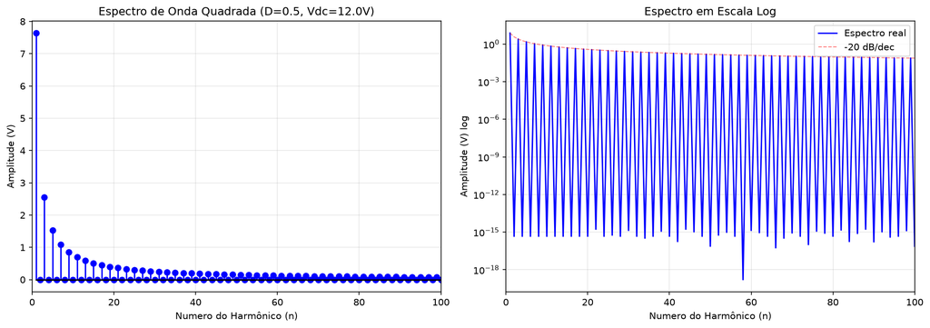

### 3.8.4 Plot de Curva de Ruído Atmosférico vs. Frequência

PYTHON

```
import numpy as np
import matplotlib.pyplot as plt

def atmos_noise_index(f_MHz, latitude=0, time=6):
    """
    Modelo simplificado de ruido atmosferico (ITU-R P.372).
    f_MHz: frequencia em MHz, latitude: latitude geografica.
    Retorna N em dB acima de kTB.
    """
    f = f_MHz / 1e3  # converter para GHz
    A = 118.0 + 30 * np.log10(f + 0.1)
    B = 20.0 * np.exp(-f * 0.5)
    C = 5.0 * (1 + 0.1 * abs(latitude))
    N = A + B + C - 10 * np.log10(1 + (f / 0.01)**2)
    return np.maximum(N, 0)

# Gerar grafico
f_kHz = np.logspace(0, 5, 1000)  # 1 kHz a 100 MHz
f_MHz = f_kHz / 1e3
N_trop = atmos_noise_index(f_MHz, latitude=0)    # equador
N_mid  = atmos_noise_index(f_MHz, latitude=40)   # temperada
N_pol  = atmos_noise_index(f_MHz, latitude=70)   # polar

fig, ax = plt.subplots(figsize=(10, 6))
ax.semilogx(f_MHz, N_trop, 'b-', linewidth=2, label='Equador (0 deg)')
ax.semilogx(f_MHz, N_mid,  'r-', linewidth=2, label='Temperada (40 deg)')
ax.semilogx(f_MHz, N_pol,  'g-', linewidth=2, label='Polar (70 deg)')
ax.set_xlabel('Frequencia (MHz)')
ax.set_ylabel('Indice de Ruido (dB acima de kTB)')
ax.set_title('Ruido Atmosferico vs. Frequencia (ITU-R P.372)')
ax.legend()
ax.grid(True, which='both', alpha=0.3)
ax.set_xlim(0.01, 100)

# Marcar fc = 10 kHz
ax.axvline(0.01, color='k', linestyle='--', alpha=0.3)
ax.text(0.015, ax.get_ylim()[1]*0.9, 'fc ~ 10 kHz', fontsize=9)
plt.tight_layout()
plt.savefig('/tmp/atmos_noise.png', dpi=150)
plt.show()

# Valores numericos
print("\nValores de indice de ruido atmosferico:")
for f in [0.01, 0.1, 1, 10, 100, 1000, 10000]:
    print(f"  f = {f:>8.2f} MHz: N = {atmos_noise_index(f, 0):6.1f} dB")
```

**Output:**

```
Valores de indice de ruido atmosferico:
  f =     0.01 MHz: N =  113.0 dB
  f =     0.10 MHz: N =  113.0 dB
  f =     1.00 MHz: N =  113.1 dB
  f =    10.00 MHz: N =  111.1 dB
  f =   100.00 MHz: N =  101.0 dB
  f =  1000.00 MHz: N =   96.4 dB
  f = 10000.00 MHz: N =   93.3 dB
```

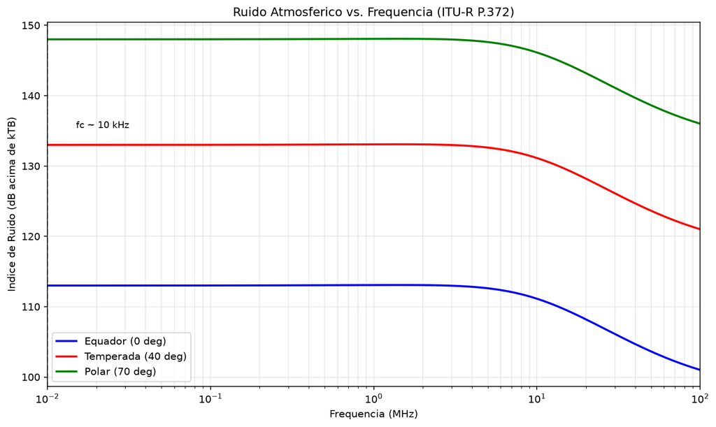

### 3.8.5 Cálculo de EIRP e Intermodulação de Terceira Ordem

PYTHON

```
import numpy as np
import matplotlib.pyplot as plt

def eirp_db(P_trans_dBm, G_ant_dBi, L_cable_dB):
    """Calcula EIRP em dBm."""
    return P_trans_dBm + G_ant_dBi - L_cable_dB

def im3_power(P_in_dBm, IP3_dBm):
    """Potencia do sinal de intermodulacao de terceira ordem."""
    return 3 * P_in_dBm - 2 * IP3_dBm

def ip3_from_measurements(P_in_dBm, P_im3_dBm):
    """Determina IP3 a partir de medidas."""
    return (3 * P_in_dBm - P_im3_dBm) / 2

# --- Exemplo: EIRP ---
print("=" * 50)
print("EXEMPLO: Calculo de EIRP")
print("=" * 50)

P_tx = 40        # dBm (10 W)
G_ant = 15       # dBi
L_cable = 2      # dB
EIRP = eirp_db(P_tx, G_ant, L_cable)
print(f"Transmissor: {P_tx} dBm ({10**(P_tx/10)*1e-3:.1f} W)")
print(f"Ganho da antena: {G_ant} dBi")
print(f"Perda do cabo: {L_cable} dB")
print(f"EIRP = {EIRP} dBm ({10**(EIRP/10)*1e-3:.1f} W)")

# --- Exemplo: Intermodulacao ---
print("\n" + "=" * 50)
print("EXEMPLO: Intermodulacao de Terceira Ordem")
print("=" * 50)

IP3 = 30  # dBm
P_in_range = np.linspace(-30, 10, 100)
P_fund = P_in_range
P_IM3 = 3 * P_in_range - 2 * IP3

fig, ax = plt.subplots(figsize=(9, 5))
ax.plot(P_in_range, P_fund, 'b-', linewidth=2, label='Sinal fundamental')
ax.plot(P_in_range, P_IM3, 'r--', linewidth=2, label='IM3 (2f1 - f2)')
ax.axhline(IP3, color='k', linestyle=':', alpha=0.5)
ax.axvline(IP3, color='k', linestyle=':', alpha=0.5)
ax.text(IP3 + 1, IP3 - 3, f'IP3 = {IP3} dBm', fontsize=10)
ax.set_xlabel('Poder de Entrada (dBm)')
ax.set_ylabel('Poder de Saida (dBm)')
ax.set_title('Intermodulacao de Terceira Ordem')
ax.legend()
ax.grid(True, alpha=0.3)
ax.set_xlim(-30, 10)
ax.set_ylim(-80, 35)
plt.tight_layout()
plt.savefig('/tmp/im3.png', dpi=150)
plt.show()

# Determinar IP3 a partir de medidas
P_in_meas = -10
P_im3_meas = -50
IP3_calc = ip3_from_measurements(P_in_meas, P_im3_meas)
print(f"P_in = {P_in_meas} dBm, P_IM3 = {P_im3_meas} dBm")
print(f"IP3 calculado = {IP3_calc} dBm")
```

**Output:**

```
==================================================
EXEMPLO: Calculo de EIRP
==================================================
Transmissor: 40 dBm (10.0 W)
Ganho da antena: 15 dBi
Perda do cabo: 2 dB
EIRP = 53 dBm (199.5 W)

==================================================
EXEMPLO: Intermodulacao de Terceira Ordem
==================================================
P_in = -10 dBm, P_IM3 = -50 dBm
IP3 calculado = 10.0 dBm
```

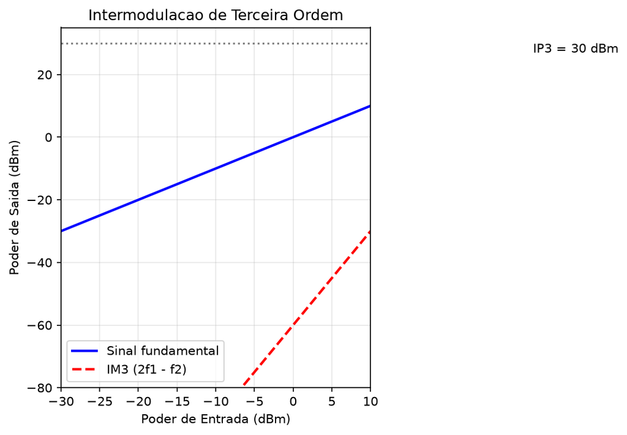

## 3.9 Lista de Exercícios Propostos

Use, quando necessário, $k_B = 1{,}381 \times 10^{-23}\,\text{J/K}$, $T_0 = 290\,\text{K}$, $c = 2{,}998 \times 10^8\,\text{m/s}$, $\eta_0 = 376{,}7\,\Omega$.

**E.1** — Calcule a potência de ruído térmico disponível de um resistor a $T = 300\,\text{K}$ em uma banda de $B = 1\,\text{MHz}$. Expresse o resultado em (a) watts, (b) dBm, (c) dBµW.

**E.2** — Uma antena recebe ruído atmosférico com $T_{\text{sky}} = 15\,000\,\text{K}$ a $f = 5\,\text{MHz}$. O receptor tem fator de ruído $F = 4\,\text{dB}$ e banda $B = 10\,\text{kHz}$. Calcule (a) a temperatura de ruído equivalente $T_e$, (b) a temperatura total do sistema, (c) a potência de ruído na entrada do receptor.

**E.3** — Mostre que para uma onda quadrada simétrica ($D = 0{,}5$), os harmônicos pares são nulos. Deduza a amplitude do 1º, 3º e 5º harmônico.

**E.4** — Um conversor buck opera com $V_{dc} = 48\,\text{V}$, $f_s = 100\,\text{kHz}$ e $D = 0{,}35$. Calcule (a) a componente DC da tensão, (b) a amplitude do 1º harmônico, (c) a amplitude do 5º harmônico, (d) a razão entre o 1º harmônico e a componente DC em dB.

**E.5** — Um MOSFET apresenta uma rampa aproximadamente linear de $0$ a $600\,\text{V}$ em $20\,\text{ns}$. Uma capacitância parasita $C_p=2\,\text{pF}$ acopla o nó a uma entrada. Calcule (a) $dV/dt$ e (b) a corrente durante a rampa. (c) A aproximação $v=iZ$ com $Z=10\,\text{k}\Omega$ produz qual valor? Explique por que ele é apenas uma estimativa local em frequência/tempo e quais elementos faltam para prever a forma e o pico reais.

**E.6** — Um transmissor de $50\,\text{W}$ alimenta uma antena com ganho $G = 12\,\text{dBi}$ através de um cabo com perda de $1{,}5\,\text{dB}$. Calcule (a) o EIRP em dBW, (b) o EIRP em watts, (c) a densidade de potência a $1\,\text{km}$ (assumindo irradiação isotrópica).

**E.7** — Dois transmissores operam em $f_1 = 900\,\text{MHz}$ e $f_2 = 901\,\text{MHz}$ através de um amplificador não-linear com $IP3 = 25\,\text{dBm}$. Calcule (a) as frequências de intermodulação de terceira ordem $f_{IM3}$ e $f_{IM3}'$, (b) se alguma cai dentro da banda $899\text{--}902\,\text{MHz}$.

**E.8** — Um sistema de recepção tem três estágios: LNA ($G_1 = 25\,\text{dB}$, $F_1 = 1{,}5\,\text{dB}$), filtro ($G_2 = -1{,}5\,\text{dB}$, $F_2 = 3\,\text{dB}$), receptor ($G_3 = 30\,\text{dB}$, $F_3 = 6\,\text{dB}$). Calcule o fator de ruído total usando a fórmula de Friis.

**E.9** — Mostre que o ruído térmico de Johnson-Nyquist tem densidade espectral plana (white noise). Considere um resistor $R$ conectado a um amperímetro ideal de banda infinita. Explique por que a potência total de ruído diverge e como isso se resolve fisicamente.

**E.10** — Um forno de micro-ondas opera em $2{,}45\,\text{GHz}$ com potência de $1000\,\text{W}$. Calcule (a) o comprimento de onda, (b) a energia de um fóton em eV, (c) a densidade de potência a $0{,}5\,\text{m}$ (assumindo $G = 0\,\text{dBi}$ isotrópico).

**E.11 (desafio)** — Deduza que, para uma transição de chaveamento com tempo de subida $\tau_r$, a frequência de corte do espectro de emissão é $f_{\text{max}} \approx 0{,}35/\tau_r$. Dica: considere o espectro de um pulso gaussiano de largura $\tau_r$.

**E.12 (desafio)** — Um enunciado afirma: “um receptor com $B=1\,\text{MHz}$, $P_{\min}=-120\,\text{dBm}$ e $T_{\text{sys}}=500\,\text{K}$ permite calcular $F$, SNR de saída e $T_e$”. (a) Mostre por que os dados são insuficientes e parcialmente redundantes; (b) calcule $k_BT_{\text{sys}}B$; (c) determine a SNR mínima implícita; (d) explique quais dados adicionais permitiriam obter $F$ e $T_e$ sem dupla contagem.

## 3.10 Gabarito

### 3.10.1 E1

Dados: $T = 300\,\text{K}$, $B = 1\,\text{MHz} = 10^6\,\text{Hz}$.

(a) Potência em watts:

$$ P_n = k_B T B = (1{,}381 \times 10^{-23}) \cdot 300 \cdot 10^6 = 4{,}143 \times 10^{-15}\,\text{W} $$

(b) Potência em dBm:

$$ P_n\,[\text{dBm}] = 10\log_{10}\left(\frac{4{,}143 \times 10^{-15}}{10^{-3}}\right) = 10\log_{10}(4{,}143 \times 10^{-12}) = \boxed{-113{,}8\,\text{dBm}} $$

(c) Potência em dBµW:

$$ P_n\,[\text{dB\mu W}] = 10\log_{10}(4{,}143 \times 10^{-9}) = \boxed{-83{,}8\,\text{dB\mu W}} $$

### 3.10.2 E2

Dados: $T_{\text{sky}} = 15\,000\,\text{K}$, $F = 4\,\text{dB}$, $B = 10^4\,\text{Hz}$.

(a) $F_{\text{lin}} = 10^{4/10} = 2{,}512$. $T_e = (2{,}512 - 1) \cdot 290 = \boxed{438\,\text{K}}$.

(b) $T_{\text{sys}} = 15\,000 + 438 = \boxed{15\,438\,\text{K}}$.

(c) $P_n = k_B T_{\text{sys}} B = 2{,}132 \times 10^{-15}\,\text{W} = \boxed{-116{,}7\,\text{dBm}}$.

### 3.10.3 E3

Para $D = 0{,}5$:

$$ V_n = \frac{2V_{dc}}{n\pi} |\sin(n\pi/2)| $$

Para $n$ par, $n=2m$: $\sin(m\pi) = 0$, logo $V_{2m} = 0$. **Harmônicos pares são nulos.**

Para $n$ ímpar: $|\sin| = 1$:

$$ \boxed{V_1 = \frac{2V_{dc}}{\pi},\; V_3 = \frac{2V_{dc}}{3\pi},\; V_5 = \frac{2V_{dc}}{5\pi}} $$

### 3.10.4 E4

Dados: $V_{dc} = 48\,\text{V}$, $D = 0{,}35$.

(a) $V_{\text{DC}} = 0{,}35 \cdot 48 = \boxed{16{,}8\,\text{V}}$.

(b) $V_1 = \frac{96}{\pi} |\sin(0{,}35\pi)| = 30{,}56 \cdot 0{,}891 = \boxed{27{,}2\,\text{V}}$.

(c) $V_5 = \frac{96}{5\pi} |\sin(1{,}75\pi)| = 6{,}11 \cdot 0{,}707 = \boxed{4{,}32\,\text{V}}$.

(d) $20\log_{10}(27{,}2/16{,}8) = \boxed{4{,}19\,\text{dB}}$.

### 3.10.5 E5

Dados: $V = 600\,\text{V}$, $t_r = 20\,\text{ns}$, $C_p = 2\,\text{pF}$, $Z = 10\,\text{k}\Omega$.

(a) $\frac{dV}{dt} = \frac{600}{20 \times 10^{-9}} = \boxed{30\,\text{V/ns}}$.

(b) $i_{\text{coupled}} = 2 \times 10^{-12} \cdot 3 \times 10^{10} = \boxed{60\,\text{mA}}$.

(c) A substituição direta dá $v=iZ=(60\,\text{mA})(10\,\text{k}\Omega)=\boxed{600\,\text{V}}$. Esse resultado extremo é um alerta sobre o modelo, não uma previsão completa: $Z$ deve ser a impedância complexa na faixa espectral da borda, e faltam capacitância da vítima, impedância da fonte, diodos de proteção, indutâncias, forma real da borda e retorno. A tensão não permanece em 600 V; é preciso resolver o circuito transitório (ou medir) para obter pico e duração.

### 3.10.6 E6

Dados: $P = 50\,\text{W} = 16{,}99\,\text{dBW}$, $G = 12\,\text{dBi}$, $L = 1{,}5\,\text{dB}$.

(a) $EIRP = 16{,}99 + 12 - 1{,}5 = \boxed{27{,}5\,\text{dBW}}$.

(b) $EIRP = 10^{2{,}75} = \boxed{562\,\text{W}}$.

(c) $S = \frac{562}{4\pi \cdot 10^6} = 4{,}47 \times 10^{-5}\,\text{W/m}^2 = \boxed{44{,}7\,\mu\text{W/m}^2}$.

### 3.10.7 E7

(a) $f_{IM3} = 2 \cdot 900 - 901 = \boxed{899\,\text{MHz}}$. $f_{IM3}' = 2 \cdot 901 - 900 = \boxed{902\,\text{MHz}}$.

(b) Ambas caem **nos limites** da banda $899\text{--}902\,\text{MHz}$. **Caso crítico**: adjacentes ao canal útil.

### 3.10.8 E8

$$ F_1 = 1{,}413,\; G_1 = 316{,}2,\; F_2 = 1{,}995,\; G_2 = 0{,}708,\; F_3 = 3{,}981 $$

$$ F_{\text{total}} = 1{,}413 + \frac{0{,}995}{316{,}2} + \frac{2{,}981}{316{,}2 \cdot 0{,}708} = 1{,}413 + 0{,}0031 + 0{,}0133 = \boxed{1{,}430} $$

$$ F_{\text{total,dB}} = \boxed{1{,}55\,\text{dB}} $$

### 3.10.9 E9

$S_V(f) = 4k_BTR$ é **constante** (independente de $f$), logo é **ruído branco**. A potência total $P = \int_0^{\infty} S_V(f)\,\frac{1}{4R}\,df$ diverge. **Resolução física**: para $f \gtrsim k_B T/h \approx 6\,\text{THz}$, a quantização exige a fórmula de Planck:

$$ S_V(f) = 4R \cdot \frac{hf}{e^{hf/(k_B T)} - 1} $$

que decai exponencialmente, tornando a integral convergente. A fórmula clássica é válida para $hf \ll k_B T$.

### 3.10.10 E10

Dados: $f = 2{,}45\,\text{GHz}$, $P = 1000\,\text{W}$.

(a) $\lambda = \frac{c}{f} = \frac{2{,}998 \times 10^8}{2{,}45 \times 10^9} = \boxed{12{,}2\,\text{cm}}$.

(b) $E = hf = (6{,}626 \times 10^{-34})(2{,}45 \times 10^9) / (1{,}602 \times 10^{-19}) = \boxed{10{,}1\,\mu\text{eV}}$.

(c) $S = \frac{1000}{4\pi \cdot 0{,}25} = \frac{1000}{\pi} = \boxed{318\,\text{W/m}^2}$.

### 3.10.11 E11

Pulso gaussiano: $p(t) = \exp(-t^2/(2\tau_r^2))$. Sua transformada:

$$ P(f) = \tau_r\sqrt{2\pi}\,\exp(-2\pi^2 f^2 \tau_r^2) $$

Espectro decai exponencialmente. Definindo $f_{\text{max}}$ quando o espectro cai a $1/e$ do valor em DC:

$$ \exp(-2\pi^2 f_{\text{max}}^2 \tau_r^2) = e^{-1} \Rightarrow 2\pi^2 f_{\text{max}}^2 \tau_r^2 = 1 $$

$$ f_{\text{max}} = \frac{1}{\pi\sqrt{2}\,\tau_r} \approx \frac{0{,}225}{\tau_r} $$

Usando o critério mais conservador $f_{\text{max}} \approx \frac{0{,}35}{\tau_r}$ (baseado em pulso gaussiano de largura FWHM), obtém-se o resultado padrão da literatura EMC. $\blacksquare$

### 3.10.12 E12

(a) $T_{\text{sys}}$ já representa o ruído total referido à entrada; multiplicá-lo novamente por $F$ seria dupla contagem. Além disso, sensibilidade só tem significado para uma SNR/BER/critério de detecção especificado. Sem separar $T_{\text{ant}}$ e $T_e$, não é possível inferir $F$.

(b) $k_BT_{\text{sys}}B=(1{,}381\times10^{-23})(500)(10^6)=6{,}905\times10^{-15}\,\text{W}=\boxed{-111{,}6\,\text{dBm}}$.

(c) $P_{\min}=-120\,\text{dBm}=10^{-15}\,\text{W}$ implicaria

$$ (SNR)_{\min}=\frac{P_{\min}}{k_BT_{\text{sys}}B}=0{,}145=\boxed{-8{,}39\,\text{dB}}. $$

Isso não é automaticamente impossível: sistemas codificados ou detectores integradores podem operar com SNR numérica negativa, dependendo da definição de banda, taxa e critério. O resultado exige que esses elementos sejam declarados.

(d) Para obter $F$ e $T_e$, forneça $T_{\text{ant}}$ e deixe claro que $T_{\text{sys}}=T_{\text{ant}}+T_e$ no mesmo plano de referência. Então $T_e=T_{\text{sys}}-T_{\text{ant}}$ e $F=1+T_e/T_0$. Alternativamente, forneça diretamente $F$ e use a forma baseada em $T_0$.

# 4. Normas, Padronizações e Ensaios de EMC

> Compatibilidade Eletromagnética — Apostila de Curso  
> Tópicos: CISPR · IEC · IEEE · ANATEL · Classes de produtos · Ensaios de imunidade · Certificação CE/FCC · Python para limites CISPR

## 4.1 Antes de começar

Ao final, você deve localizar a família normativa aplicável, distinguir emissão de imunidade e interpretar detector, distância, arranjo, margem e incerteza. **Diagnóstico:** ficar abaixo de uma curva desenhada no gráfico basta para declarar conformidade? **Evidência mínima:** escrever um plano de ensaio que identifique edição normativa, porta, faixa, detector, configuração, critério de desempenho e decisão de conformidade.

> **Atenção:** tabelas e níveis neste capítulo são educacionais. Confirme sempre a edição vigente, *amendments*, classificação do produto, condições do ensaio e regras da jurisdição.

## 4.2 Arquitetura da Padronização EMC

> **Controle de edição:** limites, níveis e procedimentos dependem da edição, emendas, produto e jurisdição. As tabelas deste capítulo são didáticas e não substituem o texto normativo adquirido nem a avaliação do laboratório acreditado. Confirme sempre o catálogo oficial antes de elaborar um plano de conformidade.

A padronização em compatibilidade eletromagnética é uma estrutura internacional hierárquica, organizada para cobrir desde os equipamentos de medida até os limites de emissão e imunidade de produtos finais. As principais organizações são:

### 4.2.1 CISPR — Comissão Internacional Especial de Ruído

O **CISPR** (Comité International Spécial des Perturbations Radioélectriques) foi criado em 1934 sob a égide da **IEC**. É o organismo central de padronização de emissões eletromagnéticas.

**Estrutura:**

| Subcomitê | Responsabilidade |
| --- | --- |
| CISPR/A | Métodos de medição e instrumentação de perturbações radioelétricas |
| CISPR/B | Interferência relacionada a equipamentos ISM, equipamentos de potência e linhas de transmissão |
| CISPR/D | EMC de equipamentos elétricos/eletrônicos em veículos e motores de combustão |
| CISPR/F | EMC de eletrodomésticos, ferramentas, luminárias e equipamentos semelhantes |
| CISPR/H | Limites para proteção de serviços de rádio e aspectos genéricos de emissão |
| CISPR/I | EMC de equipamentos de tecnologia da informação, multimídia e receptores |

**Como ler a tabela:** as letras identificam **subcomitês técnicos**, não classes de produto nem partes de uma única norma. Os títulos e a estrutura podem ser reorganizados; para um projeto real, consulte a página oficial do CISPR e o catálogo IEC.

**Atuação:** Publica as normas fundamentais de emissão (família CISPR) e os equipamentos de medida (CISPR 16).

### 4.2.2 IEC — Comissão Eletrotécnica Internacional

A **IEC** (International Electrotechnical Commission) publica normas que abrangem toda a gama de EMC, incluindo imunidade. O **TC 77** coordena EMC, apoiado pelos subcomitês **SC 77A** (fenômenos de baixa frequência), **SC 77B** (fenômenos de alta frequência) e **SC 77C** (transientes de alta potência). O CISPR trata sobretudo de perturbações radioelétricas e proteção da recepção. A norma de produto aplicável pode ser elaborada por outro comitê, usando publicações básicas desses grupos.

A família **IEC 61000** é a norma guarda-chuva de EMC, dividida em partes:

- **Parte 1:** Generalidades (terminologia, níveis)
- **Parte 2:** Compatibilidade ambiental
- **Parte 3:** Limites de emissão
- **Parte 4:** Ensaios de imunidade e proteção
- **Parte 5:** Especificações de produto e norma de produto
- **Parte 6:** Normas genéricas

### 4.2.3 IEEE — Normas Específicas

O **IEEE** (Institute of Electrical and Electronics Engineers) publica normas específicas para aplicações particulares:

| Norma | Escopo |
| --- | --- |
| IEEE P1100 | Práticas de proteção de equipamentos eletrônicos contra EMI |
| IEEE P519 | Controle de harmônicos em sistemas de potência |
| IEEE C62.41 | Surges em sistemas de baixa tensão |
| IEEE 1180 | Guia para avaliação de desempenho de blindagem |

### 4.2.4 ANATEL no Brasil

A **ANATEL** (Agência Nacional de Telecomunicações) disciplina a avaliação da conformidade e a homologação de produtos para telecomunicações. O marco é o **Regulamento de Avaliação da Conformidade e de Homologação de Produtos para Telecomunicações**, aprovado pela **Resolução nº 715, de 23 de outubro de 2019**, com alterações posteriores e procedimentos/requisitos complementares publicados por Atos. Não existe, nesse contexto, uma “RDC 242/2019”. O processo contempla, conforme o produto:

- Limites de emissões conduzidas e irradiadas de equipamentos de telecomunicação
- Requisitos de imunidade para equipamentos de estação fixa e móvel
- requisitos técnicos e procedimentos operacionais aplicáveis à família do produto;
- ensaios em laboratórios reconhecidos quando exigidos;
- certificação ou declaração de conformidade, seguida de homologação.

**Observação:** não se deve concluir que todo equipamento eletroeletrônico geral é automaticamente regulado pelo Inmetro. A compulsoriedade depende do produto e do regulamento brasileiro específico. Primeiro classifique o produto e identifique as autoridades e programas aplicáveis; alguns produtos não têm certificação EMC compulsória genérica.

## 4.3 Família CISPR — Estrutura e Escopo

### 4.3.1 CISPR 16 — Equipamentos de Medida

A norma **CISPR 16-1-1** especifica aparelhos de medição de perturbação e imunidade, incluindo receptores de medição com detectores como pico, quasi-pico e média. “SESA” não é uma denominação normativa geral para receptor EMI.

| Detector | Aplicação |
| --- | --- |
| **Peak (P)** | Varredura rápida, máxima emissão |
| **Quasi-Peak (QP)** | Medida regulatória para EMI repetitiva |
| **Average (AVG)** | Medida para EMI contínua |

O detector **quasi-peak** é o mais importante para conformidade regulatória, pois pondera as emissões de acordo com sua frequência de repetição e amplitude — uma emissão rara terá leitura QP muito menor que a de pico, mesmo com a mesma amplitude.

**CISPR 16-2-1** especifica **métodos de medição de perturbações conduzidas**, especialmente de 9 kHz a 30 MHz. Ela não é uma especificação de analisadores de figura de ruído.

**CISPR 16-1-2** trata de **dispositivos de acoplamento para medições de perturbações conduzidas**, como redes artificiais. Requisitos de antenas e sítios para medição de perturbações radiadas aparecem em outras partes da série CISPR 16; por isso, o número completo da parte deve sempre acompanhar uma afirmação.

### 4.3.2 CISPR 32 — Multimídia Equipment

A **CISPR 32** (substituindo CISPR 22 e CISPR 13) aplica-se a equipamentos de multimídia (computadores, TVs, equipamentos de comunicação integrados):

- **Emissões conduzidas:** 150 kHz – 30 MHz
- **Emissões irradiadas:** 30 MHz – 6 GHz (até 18 GHz opcional)
- **Classes:** A (industrial) e B (residencial)

A norma define limites em dBµV (conduzido) e dBµV/m (irradiado) para ambos os detectores QP e AVG.

### 4.3.3 CISPR 35 — Equipamentos multimídia: imunidade

A **CISPR 35** estabelece requisitos de **imunidade para equipamentos multimídia**. Seu escopo é mais amplo que equipamentos de telecomunicações e complementa a abordagem de emissão da CISPR 32:

- Suscetibilidade a campos RF irradiados
- Suscetibilidade a transientes conduzidos
- Efeitos de emissões de outros equipamentos na funcionalidade

Em termos didáticos, CISPR 32 trata emissões e CISPR 35 trata imunidade do conjunto multimídia, mas a edição vigente e as exclusões de escopo precisam ser verificadas.

### 4.3.4 CISPR 12 — Veículos

A **CISPR 12** estabelece limites de emissões de RF de veículos, embarcações e equipamentos movidos a motor:

- **Emissões conduzidas** nos terminais de bateria
- **Emissões irradiadas** do veículo em movimento

Esta norma é particularmente importante para veículos elétricos, cujos inversores geram emissões significativas.

### 4.3.5 CISPR 14-1 — Eletrodomésticos

A **CISPR 14-1** aplica-se a eletrodomésticos, ferramentas elétricas e aparelhos similares dentro de seu próprio escopo. Ela não foi incorporada genericamente à CISPR 32, que trata de equipamentos multimídia; a norma aplicável depende da função e classificação do produto.

- Eletrodomésticos domésticos
- Ferramentas elétricas portáteis
- Aparelhos de iluminação

### 4.3.6 CISPR 11 — ISM Equipment

A **CISPR 11** cobre **equipamentos ISM** (Industrial, Scientific, Medical):

- Geradores de plasma
- Fornalhos a arco
- Equipamentos de diatermia
- Fornos de micro-ondas industriais

Os limites são mais flexíveis que para produtos de consumo, reconhecendo que o ruído de tais equipamentos é inerente à sua função.

## 4.4 Família IEC — Ensaios de Imunidade

A família **IEC 61000-4** define os ensaios de imunidade eletromagnética. Cada parte aborda um tipo de distúrbio:

### 4.4.1 IEC 61000-4-2 — ESD (Electro-Static Discharge)

O ensaio de descarga eletrostática simula a descarga de uma pessoa carregada contra o equipamento:

- **Nível de teste comum:** 8 kV contato (contact discharge), 15 kV ar (air discharge)
- **Gerador:** 150 pF, 330 Ω (modelo de descarga)
- **Polaridade:** positiva e negativa
- **Taxa:** 1 descarga/s (contato), 1 descarga/2s (ar)

**Parâmetros de forma de onda:**

$$ \boxed{ \begin{array}{ll} \text{Tempo de subida:} & \leq 1\,\text{ns} \\ \text{Tempo de meia-pulso:} & 30\,\text{ns} \pm 15\,\text{ns} \end{array} } $$

**Método de ensaio:**

| Tipo | Posição | Nível Contato | Nível Ar |
| --- | --- | --- | --- |
| Contato | Superfície acessível | ±8 kV | — |
| Ar | Superfície acessível | — | ±15 kV |
| Contato | Fendas e ranhuras | ±8 kV | — |

### 4.4.2 IEC 61000-4-3 — Radiated, RF Electromagnetic Field

Ensaio com campo RF irradiado em antena:

- **Faixa de frequência:** 80 MHz – 6 GHz (ou até 8 GHz, 80 MHz – 1 GHz)
- **Modulação:** AM 80% a 1 kHz, 50% para 1 GHz – 6 GHz
- **Nível de teste ambiente residencial/comercial:** 3 V/m
- **Nível de teste ambiente industrial:** 10 V/m

**Mecanismo de acoplamento:** O campo RF se acopla aos cabos e estruturas do equipamento, convertendo-se em tensões correntes conduzidas.

### 4.4.3 IEC 61000-4-4 — EFT/Burst (Electrical Fast Transient)

Ensaio de transientes rápidos (burst) injetados nos terminais de alimentação e sinal:

**Parâmetros do gerador (circuito equivalente):**

$$ \boxed{ \begin{array}{l} R_s = 50\,\Omega \\ C_s = 50\,\text{pF} \\ \text{Pulso: } 5\,\text{ns} \text{ (subida)},\; 50\,\text{ns} \text{ (meia-altura)} \\ \text{Burst: } 300\,\text{ms} \text{ intervalo entre bursts} \end{array} } $$

### 4.4.4 IEC 61000-4-5 — Surge

Ensaio de surtos (sobretensões de alta energia):

- **Nível de teste:** 1 kV diferencial (line-to-line), 2 kV common-mode (line-to-ground)
- **Forma de onda 1,2/50 µs:** tensão (1,2 µs de subida, 50 µs de meia-altura)
- **Forma de onda 5/50 µs:** corrente (5 µs de subida, 50 µs de meia-altura)

**Circuitos de injeção:**

$$ \boxed{ \begin{array}{ll} \text{Diferencial:} & 32\,\Omega,\; 500\,\mu\text{H} \\ \text{Common-mode:} & 32\,\Omega,\; 500\,\mu\text{H} \end{array} } $$

### 4.4.5 IEC 61000-4-6 — Conducted Immunity

Ensaio de imunidade conduzida: injeta-se um sinal RF nos cabos de alimentação e sinal:

- **Frequência:** 150 kHz – 80 MHz
- **Nível de teste:** 10 V (alimentação), 3 V (sinal)
- **Modulação:** AM 80% a 1 kHz
- **Acoplamento:** via rede de acoplamento/desacoplamento (CDN) ou clamp indutivo

### 4.4.6 IEC 61000-4-8 — Campo Magnético de Frequência da Rede

Ensaio para equipamentos próximos a linhas de transmissão:

- **Frequência:** 50 Hz ou 60 Hz
- **Nível de teste:** 1 A/m (ambiente residencial/comercial), 10 A/m (industrial)
- **Método:** bobina de Helmholtz ou solenoide

### 4.4.7 IEC 61000-4-11 — Voltage Dips e Interruptions

Ensaio de mergulhos e interrupções de tensão:

| Teste | Tipo | Duração | Redução de tensão |
| --- | --- | --- | --- |
| 1 | Dip | 0,5 ciclo (10 ms @ 50 Hz) | 0% |
| 2 | Dip | 1 ciclo | 70% |
| 3 | Dip | 5 ciclos | 70% |
| 4 | Dip | 25 ciclos | 70% |
| 5 | Dip | 1 segundo | 70% |
| 6 | Interrupção | 1 segundo | 100% |
| 7 | Variation | 1 minuto | 5% |

## 4.5 Classes de Produtos e Requisitos por Classe

### 4.5.1 Classe A (Industrial) vs. Classe B (Residencial)

A classificação em classes reflete o **ambiente de uso** do produto:

**Classe A** — Equipamentos para ambiente industrial:

- Limites de emissão **mais permissivos**
- Considera que o ambiente industrial já possui interferências significativas
- Aplicável a máquinas industriais, equipamentos de telecomunicação de rede

**Classe B** — Equipamentos para ambiente residencial:

- Limites de emissão **mais restritivos**
- Considera a proximidade com receptores sensíveis (rádio, TV, dispositivos médicos)
- Aplicável a computadores pessoais, eletrodomésticos, dispositivos de consumo

### 4.5.2 Limites de Emissão Conduzida — CISPR 32

Os limites de emissão conduzida da CISPR 32 para a banda de 150 kHz – 30 MHz são:

| Frequência (MHz) | Classe A (dBµV) | Classe B (dBµV) |
| --- | --- | --- |
| 0,15 – 0,5 | 79 QP / 66 AVG | 79 QP / 66 AVG |
| 0,5 – 30 | 73 QP / 60 AVG | 56 QP / 50 AVG |

**Observação:** Os limites acima são para medida em linha (L) e neutro (N), com rede de impedância de linha (LISN) de 50 Ω / 50 µH.

### 4.5.3 Limites de Emissão Radiada — CISPR 32

Os limites de emissão irradiada para 30 MHz – 1 GHz:

[output not shown]

Acima de 1 GHz, **não use uma fórmula logarítmica genérica** como substituto da tabela normativa. Limites, detectores (pico/média), largura de banda, distância e frequência superior de ensaio dependem da edição e das características do equipamento. O procedimento correto é localizar a linha aplicável na edição vigente da CISPR 32 (ou na adoção regional correspondente) e registrar todos esses parâmetros.

### 4.5.4 Gráficos de Limites vs. Frequência

A figura abaixo ilustra a transição entre os diferentes regimes de limites:

[output not shown]

## 4.6 Ensaios de Conformidade — Metodologia

### 4.6.1 Câmara Semianecóica

A **câmara semianecóica** é o ambiente de medida para ensaios de emissão radiada e imunidade radiada:

**Características:**

- **Paredes e teto:** cobertos com materiais absorventes (espuma de ferrite + carbônio)
- **Piso:** condutivo (grade metálica aterrada)
- **Dimensões mínimas:** determinadas pela frequência máxima de ensaio

O **PSL (Pre-Site Verification — Verificação de Site)** é realizado antes de cada campanha de medida para garantir a uniformidade do campo e a rejeição de reflexões:

$$ \boxed{\text{PSL} = \left| \frac{V_{\text{min}}}{V_{\text{max}}} \right|_{\text{site}} \leq 0{,}5 \quad \text{(ou } \leq -6\,\text{dB})} $$

### 4.6.2 Setup de Teste

O **equipamento de teste** típico inclui:

1. **Antena de medida** (dipolo log-periódico, horn)
2. **Receptor EMI** ou analisador de espectro com detector QP
3. **LISN** (Line Impedance Stabilization Network) para medidas conduzidas
4. **Mesa de teste** não condutiva (Classe B) ou condutiva aterrada (Classe A)
5. **DUT (Device Under Test)** com cabos em configuração de referência

### 4.6.3 Procedimento de Medida

**Scan de emissão:**

1. Medir com detector **Peak** em todas as frequências (varredura rápida)
2. Medir com detector **QP** nas frequências onde o Peak excedeu o limite (verificação regulatória)
3. Medir com detector **Average** para caracterização adicional

**Rotations e heights:** A antena de medida é posicionada a 3 m, 5 m ou 10 m do DUT (dependendo do tamanho do DUT e da frequência). A altura da antena é varrida de 1 m a 4 m. O DUT é girado em 360°.

### 4.6.4 Incerteza de Medida

A **incerteza expandida** de uma medida EMC é:

$$ \boxed{U = k \cdot u_c} $$

onde:

- $u_c$ é a incerteza combinada (contribuições de antena, receptor, LISN, repetibilidade)
- $k = 2$ para nível de confiança de aproximadamente 95%

A CISPR 16-4-3 especifica as incertezas típicas:

| Tipo de medida | Incerteza expandida (k=2) |
| --- | --- |
| Emissão conduzida (QP) | 3–4 dB |
| Emissão radiada (QP) | 4–5 dB |
| Emissão radiada (Peak) | 3–4 dB |

**Importante:** Ao avaliar a conformidade, a margem de conformidade deve ser calculada como:

$$ \boxed{M = E_{\text{medida}} - E_{\text{limite}}} $$

## 4.7 Certificação e Marcação CE/FCC

### 4.7.1 Processo de Certificação Passo-a-Passo

1. **Identificação das normas aplicáveis** — CISPR, IEC 61000, FCC Part 15, etc.
2. **Testes de pré-conformidade** — em câmara semianecóica de laboratório
3. **Correção de problemas** — blindagem, filtragem, layout
4. **Testes de conformidade** — em laboratório acreditado (NABCEL no Brasil, TB notified body na Europa)
5. **Montagem do dossier técnico** — relatórios de teste, desenhos, esquemas
6. **Declaração de Conformidade** — documento assinado pelo fabricante
7. **Afixação da marcação** — CE, FCC, etc.

### 4.7.2 Marcação CE

A **marcação CE** indica conformidade com as diretivas europeias aplicáveis:

- **Diretiva EMC 2014/30/EU** — Compatibilidade Eletromagnética
- **Diretiva RED 2014/53/EU** — Equipamentos de Rádio
- **Diretiva LVD 2014/35/EU** — Baixa Tensão (segurança)

**Documentação obrigatória:**

- Declaração UE de Conformidade
- Dossier técnico (desenhos, esquemas, relatórios de teste)
- Manual de instalação e operação
- Marcação visível, legível e indelével no produto

### 4.7.3 FCC Part 15 — Subpartes

A **Federal Communications Commission** (EUA) regula emissões por meio do **47 CFR Part 15**:

| Subparte | Aplicação |
| --- | --- |
| **15.31** | Procedimentos gerais de medição |
| **15.33** | Faixas de frequência de medição de emissões radiadas |
| **15.107** | Limites conduzidos para radiadores não intencionais |
| **15.109** | Limites radiados para radiadores não intencionais |
| **15.207** | Limites conduzidos gerais aplicáveis a muitos radiadores intencionais |
| **15.247** | Dispositivos de banda larga (ISM bands) |
| **15.249** | Transmissores de RF para dispositivos de baixa potência |

Os limites FCC são tabelas por faixa, classe, porta, detector e distância; não são um único valor constante para 30–1000 MHz e não distinguem linha e neutro por dois limites genéricos. Para um ensaio, consulte diretamente o parágrafo aplicável no **47 CFR vigente**. O raciocínio de conversão entre $\mu\text{V}$ e $\text{dB\mu V}$ continua válido, mas o valor de entrada deve vir da regra correta.

## 4.8 Exercícios Resolvidos em Python

### 4.8.1 Protocolo computacional

**Objetivo:** interpretar limites, detectores, margem e incerteza sem transformar exemplos em certificados. **Rastreabilidade:** registre edição normativa, distância, detector, RBW e classe. **Validação:** separe margem nominal, incerteza expandida e regra de decisão aplicada.

### 4.8.2 Plot de Limites de Emissão CISPR 32 (Classe A vs. B)

PYTHON

```
import numpy as np
import matplotlib.pyplot as plt

def cispr32_conducted_limits(f_MHz):
    """
    Calcula limites de emissao conduzida CISPR 32.
    f_MHz: frequencia em MHz.
    Retorna limites QP e AVG para Classe A e B em dBuV.
    """
    # Classe A
    if f_MHz <= 0.5:
        clsA_QP = 79.0
        clsA_AVG = 66.0
    else:
        clsA_QP = 73.0
        clsA_AVG = 60.0

    # Classe B
    if f_MHz <= 0.5:
        clsB_QP = 79.0
        clsB_AVG = 66.0
    else:
        clsB_QP = 56.0
        clsB_AVG = 50.0

    return clsA_QP, clsA_AVG, clsB_QP, clsB_AVG

# Plot
f_MHz = np.logspace(-0.8, 1.5, 500)  # 0.16 MHz a 31.6 MHz
clsA_QP, clsA_AVG, clsB_QP, clsB_AVG = [], [], [], []

for f in f_MHz:
    qa, aa, qb, ab = cispr32_conducted_limits(f)
    clsA_QP.append(qa); clsA_AVG.append(aa)
    clsB_QP.append(qb); clsB_AVG.append(ab)

fig, ax = plt.subplots(figsize=(10, 6))
ax.plot(f_MHz, clsA_QP, 'b-', linewidth=2, label='Classe A (QP)')
ax.plot(f_MHz, clsA_AVG, 'b--', linewidth=1.5, label='Classe A (AVG)')
ax.plot(f_MHz, clsB_QP, 'r-', linewidth=2, label='Classe B (QP)')
ax.plot(f_MHz, clsB_AVG, 'r--', linewidth=1.5, label='Classe B (AVG)')

ax.set_xscale('log')
ax.set_xlabel('Frequencia (MHz)')
ax.set_ylabel('Limite (dBuV)')
ax.set_title('Limites de Emissao Conduzida CISPR 32')
ax.legend()
ax.grid(True, which='both', alpha=0.3)
ax.set_xlim(0.15, 30)
plt.tight_layout()
plt.savefig('/tmp/cispr32_conducted.png', dpi=150)
plt.show()

print("Valores numericos:")
for f in [0.15, 0.5, 1, 10, 30]:
    qa, aa, qb, ab = cispr32_conducted_limits(f)
    print(f"  f={f:>5.2f} MHz: A(QP)={qa:.0f} A(AVG)={aa:.0f} B(QP)={qb:.0f} B(AVG)={ab:.0f}")
```

**Output:**

```
Valores numericos:
  f= 0.15 MHz: A(QP)=79 A(AVG)=66 B(QP)=79 B(AVG)=66
  f= 0.50 MHz: A(QP)=79 A(AVG)=66 B(QP)=79 B(AVG)=66
  f= 1.00 MHz: A(QP)=73 A(AVG)=60 B(QP)=56 B(AVG)=50
  f=10.00 MHz: A(QP)=73 A(AVG)=60 B(QP)=56 B(AVG)=50
  f=30.00 MHz: A(QP)=73 A(AVG)=60 B(QP)=56 B(AVG)=50
```

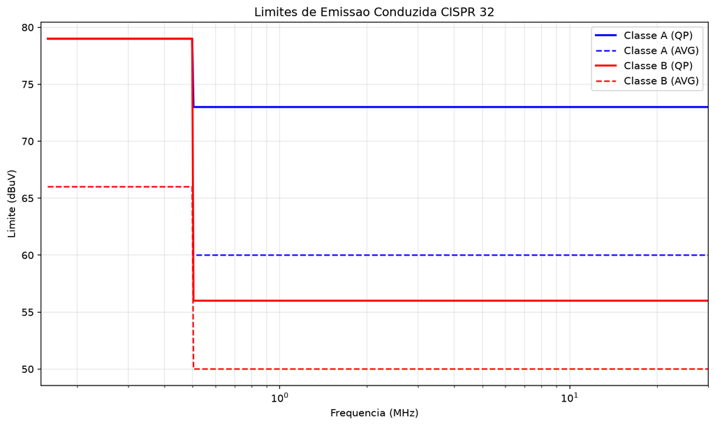

### 4.8.3 Cálculo de Margem de Conformidade

PYTHON

```
import numpy as np
import matplotlib.pyplot as plt

def compliance_margin(E_measure, E_limit, U_expanded=5.0):
    """
    Calcula margem de conformidade e status.
    E_measure, E_limit: em dBuV/m.
    U_expanded: incerteza expandida (k=2).
    Retorna: margem, status (pass/fail/uncertain).
    """
    margin = E_measure - E_limit
    if margin < -U_expanded:
        status = "FAIL"
    elif margin > 0:
        status = "PASS"
    else:
        status = "UNCERTAIN"
    return margin, status

# Simulacao: medidas de 20 produtos em 5 frequencias
np.random.seed(42)
frequencies = np.array([30, 50, 100, 200, 500])  # MHz
n_products = 20

fig, axes = plt.subplots(1, 2, figsize=(14, 5))

# Grafico 1: Medidas vs limites
for i in range(n_products):
    # Simula medidas com algum ruido
    E_meas = np.array([37 + np.random.normal(0, 3) for _ in frequencies])
    E_lim = np.full_like(frequencies, 37.0)
    axes[0].semilogx(frequencies, E_meas, 'b.', alpha=0.3)

axes[0].axhline(37, color='r', linewidth=2, label='Limite Classe B')
axes[0].set_xlabel('Frequencia (MHz)')
axes[0].set_ylabel('Emissao (dBuV/m)')
axes[0].set_title('Medidas de Emissao Radiada (20 produtos)')
axes[0].legend()
axes[0].grid(True, alpha=0.3)
axes[0].set_xlim(20, 1000)

# Grafico 2: Distribuicao de margens
margins = []
statuses = {'PASS': 0, 'FAIL': 0, 'UNCERTAIN': 0}
for i in range(n_products * 5):
    E_m = 35 + np.random.normal(0, 4)
    margin, status = compliance_margin(E_m, 37.0, 5.0)
    margins.append(margin)
    statuses[status] += 1

axes[1].hist(margins, bins=15, color='steelblue', edgecolor='black', alpha=0.7)
axes[1].axvline(0, color='green', linestyle='--', linewidth=2, label='Margem = 0')
axes[1].axvline(-5, color='red', linestyle='--', linewidth=2, label='Margem = -U')
axes[1].set_xlabel('Margem de Conformidade (dB)')
axes[1].set_ylabel('Numero de Medidas')
axes[1].set_title('Distribuicao de Margens')
axes[1].legend()
axes[1].grid(True, alpha=0.3)

# Resumo
print("Resumo de Conformidade:")
for status, count in statuses.items():
    print(f"  {status}: {count} medidas ({count/(n_products*5)*100:.1f}%)")

plt.tight_layout()
plt.savefig('/tmp/compliance_margin.png', dpi=150)
plt.show()

# Exemplo numerico
E_meas_example = 33.0
E_lim_example = 37.0
margin, status = compliance_margin(E_meas_example, E_lim_example, 5.0)
print(f"\nExemplo: Medida={E_meas_example} dBuV/m, Limite={E_lim_example} dBuV/m")
print(f"Margem = {margin:.1f} dB, Status = {status}")
```

**Output:**

```
Resumo de Conformidade:
  PASS: 26 medidas (26.0%)
  FAIL: 28 medidas (28.0%)
  UNCERTAIN: 46 medidas (46.0%)

Exemplo: Medida=33.0 dBuV/m, Limite=37.0 dBuV/m
Margem = -4.0 dB, Status = UNCERTAIN
```

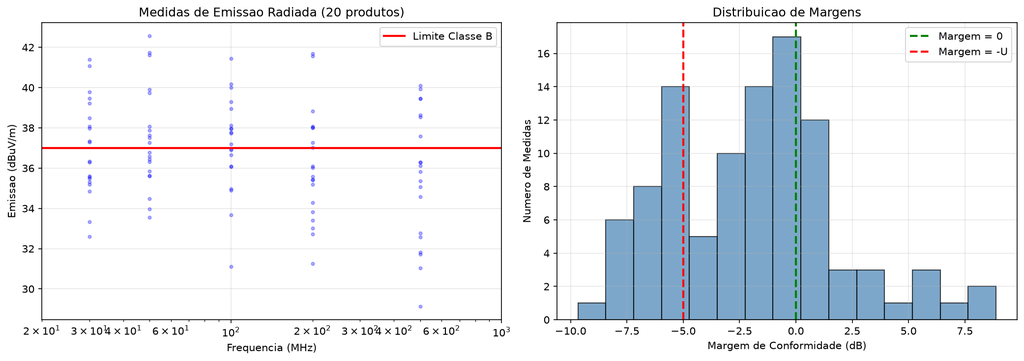

### 4.8.4 Simulação de Ensaio ESD — Curva de Tensão

PYTHON

```
import numpy as np
import matplotlib.pyplot as plt

def esd_waveform(t, C=150e-12, R=330):
    """
    Simula a forma de onda de corrente de descarga ESD (modelo de 2 exponentes).
    t: array de tempos.
    C = 150 pF (capacitancia do modelo)
    R = 330 ohms (resistencia do modelo)
    """
    tau1 = 0.6e-9    # tempo de subida (600 ps)
    tau2 = 35e-9     # tempo de caida (35 ns)
    # Forma de onda de corrente normalizada
    i = np.exp(-t/tau2) - np.exp(-t/tau1)
    i = np.maximum(i, 0)
    # Normalizar para pico = 1
    return i / np.max(i)

def esd_current(t, voltage, C=150e-12, R=330):
    """Calcula corrente de descarga ESD para uma tensao de descarga."""
    normalized = esd_waveform(t, C, R)
    I_peak = voltage / R  # corrente de pico aproximada
    return I_peak * normalized

# Simular diferentes niveis de tensao
t = np.linspace(0, 100e-9, 5000)  # 0 a 100 ns
voltages = [4, 8, 15]  # kV
colors = ['g', 'b', 'r']

fig, (ax1, ax2) = plt.subplots(2, 1, figsize=(12, 8))

for V, c in zip(voltages, colors):
    I = esd_current(t, V * 1000)
    ax1.plot(t * 1e9, I, c=c, linewidth=2, label=f'{V} kV')

ax1.set_xlabel('Tempo (ns)')
ax1.set_ylabel('Corrente (A)')
ax1.set_title('Forma de Onda de Corrente ESD (IEC 61000-4-2)')
ax1.legend()
ax1.grid(True, alpha=0.3)
ax1.set_xlim(0, 50)

# Tensao no DUT (simulacao simplificada)
R_dut = 50  # impedancia do DUT (ohms)
for V, c in zip(voltages, colors):
    V_dut = esd_current(t, V * 1000) * R_dut
    ax2.plot(t * 1e9, V_dut, c=c, linewidth=2, label=f'{V} kV -> DUT')

ax2.set_xlabel('Tempo (ns)')
ax2.set_ylabel('Tensao no DUT (V)')
ax2.set_title('Tensao Induzida no Equipamento (DUT)')
ax2.legend()
ax2.grid(True, alpha=0.3)
ax2.set_xlim(0, 50)

plt.tight_layout()
plt.savefig('/tmp/esd_waveform.png', dpi=150)
plt.show()

# Parametros de forma de onda
print("Parametros IEC 61000-4-2 ESD:")
print(f"  Capacitancia do modelo: 150 pF")
print(f"  Resistencia do modelo: 330 ohms")
print(f"  Tempo de subida: <= 1 ns")
print(f"  Tempo de meia-pulso: 30 ns +/- 15 ns")
print(f"\nCorrentes de pico aproximadas:")
for V in voltages:
    print(f"  {V} kV -> I_peak ~ {V*1000/330:.0f} A")
```

**Output:**

[output not shown]

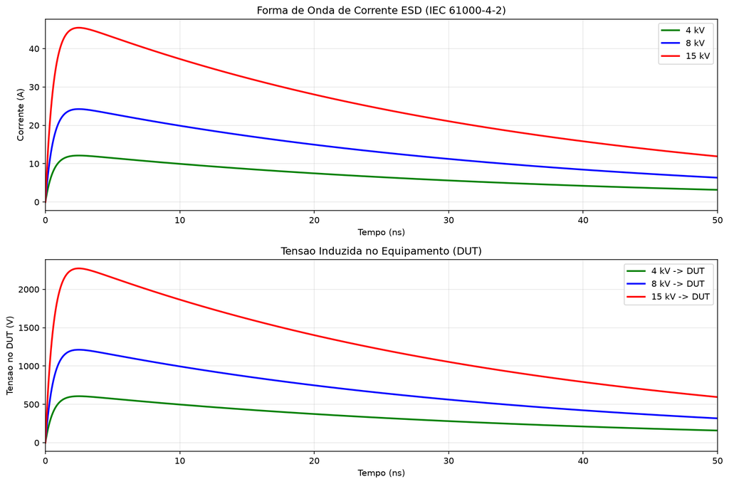

## 4.9 Lista de Exercícios Propostos

Use, quando necessário, $k_B = 1{,}381 \times 10^{-23}\,\text{J/K}$, $T_0 = 290\,\text{K}$.

**E.1** — Explique a diferença entre os detectores **Peak**, **Quasi-Peak** e **Average** de um receptor EMI. Por que a CISPR exige medida QP para conformidade regulatória e não apenas Peak?

**E.2** — Um produto deve ser certificado para a diretiva EMC europeia. Liste as etapas do processo de certificação CE e os documentos obrigatórios.

**E.3** — Explique por que não se pode calcular um limite CISPR 32 acima de $1\,\text{GHz}$ por uma fórmula universal dependente apenas da frequência. Liste os dados normativos que devem ser registrados ao extrair o limite aplicável.

**E.4** — Um ensaio de ESD é realizado a $8\,\text{kV}$ contato. Qual é a corrente de pico aproximada no modelo de descarga? Qual é a energia armazenada no capacitor de $150\,\text{pF}$ antes da descarga?

**E.5** — Um equipamento emite $42\,\text{dB\mu V/m}$ a $100\,\text{MHz}$ em um ensaio radiado. O limite CISPR 32 Classe B a $100\,\text{MHz}$ é $30\,\text{dB\mu V/m}$. Calcule (a) a margem de não conformidade, (b) se o resultado é conclusivo com incerteza expandida $U = 5\,\text{dB}$.

**E.6** — Um trem didático de EFT/Burst usa frequência de repetição de pulsos de $5\,\text{kHz}$ e duração ativa de $15\,\text{ms}$. Calcule (a) o número de pulsos em cada burst e (b) o tempo ativo acumulado em 3 bursts. Explique por que isso não determina sozinho a duração normativa total do ensaio.

**E.7** — Calcule os limites de emissão conduzida CISPR 32 Classe B em $\text{dB\mu V}$ e em $\mu\text{V}$ para $f = 1\,\text{MHz}$ (QP).

**E.8** — Um laboratório mede uma emissão radiada de $34\,\text{dB\mu V/m}$ a $300\,\text{MHz}$. O limite Classe B é $37\,\text{dB\mu V/m}$. A incerteza expandida é $4{,}5\,\text{dB}$. O produto é conforme? Justifique usando o conceito de margem de conformidade.

**E.9** — Compare os limites de emissão conduzida CISPR 32 Classe A e Classe B para $f = 10\,\text{MHz}$. Qual é a diferença em dB? O que essa diferença representa em termos de tensão no LISN?

**E.10** — Um receptor de banda $B = 1\,\text{kHz}$ opera com $T_{\text{sys}} = 290\,\text{K}$. Qual é a potência de ruído térmico disponível em dBm? Se o receptor precisa de $SNR = 10\,\text{dB}$ para operação, qual é a potência mínima do sinal?

**E.11 (desafio)** — A incerteza expandida $U = k \cdot u_c$ depende de múltiplas contribuições. Liste pelo menos 5 contribuições para a incerteza de uma medida de emissão radiada e indique quais tendem a dominar em cada faixa de frequência.

**E.12 (desafio)** — Explique por que não existe uma conversão universal entre leituras QP e AVG baseada apenas no *duty cycle*. Indique quais propriedades do pulso e do receptor precisariam ser conhecidas para prever as duas leituras.

## 4.10 Gabarito

### 4.10.1 E1

Os três detectores funcionam diferentemente:

- **Peak (P):** captura o valor máximo instantâneo do sinal. É o mais sensível e rápido, mas não reflete o impacto real da interferência no receptor.
- **Quasi-Peak (QP):** pondera a amplitude pela frequência de repetição. Um pulso isolado tem leitura QP muito menor que a de pico. Um pulso repetitivo tem QP ≈ Peak. A ponderação é feita por uma rede RC com constante de carga $0{,}2\,\text{ms}$ e descarga $1\,\text{s}$.
- **Average (AVG):** calcula a média do envelope ao longo do tempo de medição.

**Por que QP é usado para conformidade:** Porque QP reflete a **importância subjetiva da interferência**. Um sinal raro (baixa taxa de repetição) é menos perturbador que um contínuo, mesmo com a mesma amplitude de pico. A CISPR usa QP porque correlaciona melhor com a percepção humana de interferência em rádios AM.

### 4.10.2 E2

**Etapas do processo de certificação CE:**

1. Identificar diretivas aplicáveis (EMC, RED, LVD)
2. Identificar normas harmonizadas (CISPR, IEC 61000)
3. Realizar testes de pré-conformidade em laboratório
4. Corrigir problemas EMC encontrados
5. Realizar a avaliação de conformidade e os ensaios pertinentes; laboratório acreditado e organismo notificado são usados quando exigidos ou escolhidos para sustentar a avaliação, mas não são sinônimos nem universalmente obrigatórios na Diretiva EMC
6. Elaborar **dossier técnico** (desenhos, esquemas, relatórios)
7. Redigir **Declaração UE de Conformidade**
8. Afixar marcação CE no produto
9. Manter documentação por 10 anos após comercialização

**Documentos obrigatórios:** Declaração UE de Conformidade, dossier técnico (relatórios de teste, desenhos, esquemas, manual), marcação CE visível.

### 4.10.3 E3

O limite depende da edição/adopção normativa, classe do equipamento, faixa, distância de medição, detector, largura de banda e condições de configuração. Acima de $1\,\text{GHz}$ também se deve identificar a frequência máxima a ensaiar e os requisitos de pico e média. Portanto, frequência sozinha não determina o limite. Um registro rastreável inclui: documento e edição/emenda, cláusula/tabela, classe e porta, faixa, detector, RBW, distância/sítio, configuração do EUT e unidades.

### 4.10.4 E4

Corrente de pico: $I_{\text{peak}} \approx \frac{V}{R} = \frac{8000}{330} = \boxed{24{,}2\,\text{A}}$.

Energia no capacitor: $E = \frac{1}{2} C V^2 = \frac{1}{2} \cdot 150 \times 10^{-12} \cdot 8000^2 = \boxed{4{,}8\,\text{mJ}}$.

### 4.10.5 E5

(a) Com os valores **fornecidos no enunciado**, a margem em relação ao limite é  
$M=42-30=\boxed{+12\,\text{dB}}$: a emissão medida excede o limite em 12 dB.

(b) Mesmo o extremo inferior do intervalo ilustrativo, $42-5=37\,\text{dB\mu V/m}$, permanece 7 dB acima do limite de 30 dBµV/m. Assim, sob uma regra que considera esse intervalo, a não conformidade é conclusiva. Em relatório real, a conclusão deve citar a regra de decisão prescrita/contratada; não basta inventar uma “zona cinza” genérica.

### 4.10.6 E6

(a) $n=f_pt_b=(5\,000)(15\times10^{-3})=\boxed{75\text{ pulsos por burst}}$.

(b) O tempo **ativo** em três bursts é $3(15\,\text{ms})=\boxed{45\,\text{ms}}$. Esse não é o tempo total do ensaio: faltam o intervalo entre bursts, a duração de aplicação por polaridade/porta e demais condições definidas pelo plano e pela edição normativa.

### 4.10.7 E7

Para $f = 1\,\text{MHz}$, CISPR 32 Classe B: $56\,\text{dB\mu V}$ (QP).

Em $\mu\text{V}$: $V = 10^{56/20}\,\mu\text{V} = \boxed{631\,\mu\text{V}}$.

### 4.10.8 E8

Margem: $M = 34 - 37 = -3\,\text{dB}$.

Zona de incerteza: $-U \leq M \leq 0$, isto é, $-4{,}5 \leq M \leq 0$.

Como $-4{,}5 \leq -3 \leq 0$, o resultado é $\boxed{\text{UNCERTAIN}}$. **Medida adicional recomendada** — o produto pode ser conforme ou não, dentro da incerteza da medida.

### 4.10.9 E9

Para $f = 10\,\text{MHz}$:

- Classe A: QP = $73\,\text{dB\mu V}$, AVG = $60\,\text{dB\mu V}$
- Classe B: QP = $56\,\text{dB\mu V}$, AVG = $50\,\text{dB\mu V}$

Diferença QP: $73 - 56 = \boxed{17\,\text{dB}}$.

Em tensão: $\Delta V_{\text{dB}} = 20\log_{10}(V_A/V_B) = 17\,\text{dB} \Rightarrow \frac{V_A}{V_B} = 10^{17/20} = \boxed{7{,}08}$.

A Classe A permite aproximadamente **7 vezes mais tensão** conduzida que a Classe B.

### 4.10.10 E10

(a) $P_n = k_B T B = (1{,}381 \times 10^{-23})(290)(1000) = 4{,}005 \times 10^{-18}\,\text{W}$.

$$ P_n\,[\text{dBm}] = 10\log_{10}(4{,}005 \times 10^{-15}) = \boxed{-144{,}0\,\text{dBm}} $$

(b) $SNR = 10\,\text{dB} = 10\times$ linear. $P_{\text{sig}} = 10 \cdot P_n = 4{,}005 \times 10^{-17}\,\text{W} = \boxed{-134{,}0\,\text{dBm}}$.

### 4.10.11 E11

Contribuições possíveis para a incerteza de emissão radiada:

1. calibração e interpolação do **fator da antena**;
2. perda, estabilidade e desadaptação do **cabo**;
3. leitura, linearidade, ruído e resposta do **receptor EMI**;
4. posicionamento, distância e repetibilidade da altura/polarização da antena e do EUT;
5. imperfeições do sítio, reflexões e validação do ambiente;
6. variação do EUT, da rede de alimentação e da configuração de cabos.

Não se pode declarar antecipadamente qual contribuição domina apenas pela frequência. Isso é determinado pelo orçamento de incerteza do sítio, método, instrumentação e configuração concretos; cada termo deve ter distribuição, divisor, coeficiente de sensibilidade e correlação documentados.

### 4.10.12 E12

Não há uma conversão universal. O detector quasi-pico não é um medidor RMS multiplicado por $\sqrt D$: sua indicação resulta da largura de banda, constantes de carga/descarga e dinâmica do detector. O detector médio também depende da definição e do método normativo aplicável.

Dois trens de pulsos podem ter o mesmo *duty cycle* e amplitudes de pico iguais, mas taxas de repetição e larguras de pulso diferentes; o QP pode responder diferentemente porque há mais ou menos tempo para carregar e descarregar entre pulsos. Para prever leituras, seriam necessários pelo menos forma e amplitude dos pulsos, largura, taxa e regularidade de repetição, RBW, constantes do detector e tempo de observação. A resposta rigorosa é obtida pelo modelo especificado para o receptor ou por medição com detectores conformes.

# 5. Introdução ao SPICE para problemas EMC

> SPICE é um simulador de circuitos. Em EMC, ele é especialmente útil para parasitas, filtros, PDN, transientes, linhas de transmissão e proteção de portas. Ele não substitui um solucionador de campos nem um ensaio de conformidade.

Uma das implementações de código aberto mais utilizadas é o [ngspice](https://ngspice.sourceforge.io/), disponível para Linux, macOS e Windows e frequentemente integrado ao KiCad.

## 5.1 Objetivos de aprendizagem

Ao final, você deve ser capaz de:

1. ler e escrever uma netlist SPICE;
2. escolher análises de ponto de operação, AC, transiente e Fourier;
3. representar componentes reais e caminhos parasitas;
4. usar modelos, subcircuitos, parâmetros e varreduras;
5. verificar passo temporal, convergência e casos-limite;
6. distinguir resultado de circuito, estimativa EMC e conformidade.

## 5.2 O que o SPICE resolve

SPICE formula as equações do circuito por análise nodal modificada. Resistores, fontes, capacitores, indutores e dispositivos não lineares tornam-se um sistema algébrico ou diferencial. Em forma compacta,

$$ \mathbf C(\mathbf x)\frac{d\mathbf x}{dt}+\mathbf G(\mathbf x)\mathbf x =\mathbf u(t). $$

Na análise AC, o circuito é linearizado em torno do ponto de operação e resolvido para cada frequência:

$$ \left(\mathbf G+j\omega\mathbf C\right)\mathbf X=\mathbf U. $$

Consequentemente, a análise AC não representa saturação harmônica de grande sinal; ela representa a resposta incremental do circuito linearizado.

## 5.3 Anatomia de uma netlist

Cada elemento ocupa uma linha. O primeiro caractere identifica o tipo; o nó `0` é a referência global.

SPICE

```
* comentário: filtro RC
V1 in 0 DC 0 AC 1
R1 in out 1k
C1 out 0 10n
.ac dec 40 100 10Meg
.print ac vm(out) vp(out)
.end
```

**Output:**

```
Circuit: generated from textbook spice code block

Doing analysis at TEMP = 27.000000 and TNOM = 27.000000

Using SPARSE 1.3 as Direct Linear Solver

No. of Data Rows : 201
                    generated from textbook spice code block
                    AC Analysis  Tue Nov 10 17:51:34  2026
--------------------------------------------------------------------------------
Index   frequency       vm(out)         vp(out)
--------------------------------------------------------------------------------
0	1.000000e+02	9.999803e-01	-6.28310e-03
1	1.059254e+02	9.999779e-01	-6.65539e-03
2	1.122018e+02	9.999752e-01	-7.04973e-03
3	1.188502e+02	9.999721e-01	-7.46744e-03
4	1.258925e+02	9.999687e-01	-7.90990e-03
5	1.333521e+02	9.999649e-01	-8.37857e-03
```

**Ver mais (204 linhas)**

[output not shown]

- `V1`: fonte entre `in` e `0`;
- `R1`: resistor entre `in` e `out`;
- `C1`: capacitor entre `out` e `0`;
- `.ac dec 40`: 40 pontos por década, aqui suficientes para localizar o polo de 15,9 kHz;
- `vm` e `vp`: magnitude e fase.

Sufixos comuns incluem `p`, `n`, `u`, `m`, `k`, `meg` e `g`. Em muitas variantes SPICE, `M` significa *milli*, não mega; use `Meg` para evitar ambiguidade.

## 5.4 Análises fundamentais

### 5.4.1 Ponto de operação

`.op` calcula tensões e correntes DC. É indispensável antes de uma análise AC de circuitos com semicondutores, pois define o ponto de linearização.

### 5.4.2 Varredura AC

SPICE

```
V1 in 0 DC 0 AC 1
R1 in out 50
L1 out n1 10u
C1 n1 0 100n
Rload n1 0 50
.ac dec 50 1k 10Meg
.print ac vm(n1) vp(n1)
.end
```

**Output:**

```
Circuit: generated from textbook spice code block

Doing analysis at TEMP = 27.000000 and TNOM = 27.000000

Using SPARSE 1.3 as Direct Linear Solver

No. of Data Rows : 201
                    generated from textbook spice code block
                    AC Analysis  Tue Nov 10 17:51:34  2026
--------------------------------------------------------------------------------
Index   frequency       vm(n1)          vp(n1)
--------------------------------------------------------------------------------
0	1.000000e+03	4.999432e-01	-1.63352e-02
1	1.047129e+03	4.999377e-01	-1.71049e-02
2	1.096478e+03	4.999317e-01	-1.79109e-02
3	1.148154e+03	4.999251e-01	-1.87548e-02
4	1.202264e+03	4.999178e-01	-1.96386e-02
5	1.258925e+03	4.999099e-01	-2.05639e-02
```

**Ver mais (204 linhas)**

[output not shown]

Com `AC 1`, a tensão de saída também representa diretamente a função de transferência, desde que a grandeza desejada seja tensão e as portas estejam corretamente definidas.

### 5.4.3 Análise transiente

SPICE

```
Vclk in 0 PULSE(0 3.3 0 500p 500p 5n 10n)
Rsrc in line 33
Cload line 0 20p
Rleak line 0 1G
.tran 50p 30n 0 25p
.print tran v(in) v(line)
.end
```

**Output:**

```
Circuit: generated from textbook spice code block

Doing analysis at TEMP = 27.000000 and TNOM = 27.000000

Using SPARSE 1.3 as Direct Linear Solver

Initial Transient Solution
--------------------------

Node                                   Voltage
----                                   -------
in                                           0
line                                         0
vclk#branch                                  0

No. of Data Rows : 1240
                    generated from textbook spice code block
                    Transient Analysis  Tue Nov 10 17:51:35  2026
```

**Ver mais (1306 linhas)**

[output not shown]

[output not shown]

[output not shown]

[output not shown]

[output not shown]

[output not shown]

[output not shown]

[output not shown]

Em `.tran tstep tstop tstart tmax`, `tstep` define o espaçamento solicitado para a saída e `tmax` limita o passo interno máximo. Para capturar uma borda, use inicialmente $t_{max}\le t_r/20$, salve ao menos 10 pontos por borda e repita com metade de `tmax`. Simule apenas os períodos necessários para observar a partida e o regime permanente.

### 5.4.4 Fourier e espectro

SPICE

```
.tran 1n 2u 1u 500p
.four 10Meg v(line)
```

Ignore o início transitório antes de analisar regime periódico. Neste exemplo, o período é 100 ns; o trecho salvo após `tstart` contém 10 períodos e a saída tem 100 amostras por período. A diretiva `.four` calcula os harmônicos a partir do período final; uma FFT do visualizador depende da janela temporal, amostragem e número inteiro de períodos.

## 5.5 Componentes reais

### 5.5.1 Capacitor com ESR e ESL

SPICE

```
.subckt CAP_REAL p n params: C=100n ESR=30m ESL=1n
L_esl p x {ESL}
R_esr x y {ESR}
C_main y n {C}
.ends CAP_REAL

Xc out 0 CAP_REAL C=100n ESR=25m ESL=700p
```

A autorressonância ideal do modelo série é

$$ f_{SR}=\frac{1}{2\pi\sqrt{ESL\,C}}. $$

### 5.5.2 Indutor real

SPICE

```
.subckt IND_REAL p n params: L=10u ESR=100m CP=5p
R_esr p x {ESR}
L_main x n {L}
C_par p n {CP}
.ends IND_REAL
```

Acima da ressonância paralela, o componente deixa de se comportar predominantemente como indutor.

### 5.5.3 Acoplamento magnético

SPICE

```
Lpri p1 p2 1m
Lsec s1 s2 1m
K1 Lpri Lsec 0.98
```

O coeficiente $k$ define $M=k\sqrt{L_1L_2}$. Para choques de modo comum, mantenha a convenção dos pontos coerente com a soma de fluxo no modo comum.

## 5.6 Fontes úteis em EMC

### 5.6.1 Pulso com bordas finitas

`PULSE(V1 V2 TD TR TF PW PER)` deve sempre declarar tempos de subida e descida realistas. Bordas zero forçam banda infinita e podem gerar resultados numéricos sem significado físico.

### 5.6.2 Fonte arbitrária comportamental

SPICE

```
BESD esd 0 V = 8000*(exp(-time/30n)-exp(-time/0.8n))
```

A sintaxe de fontes comportamentais varia entre simuladores. Confirme a documentação e normalize a forma para o pico desejado.

### 5.6.3 Excitação por corrente

SPICE

```
Icm chassis 0 PULSE(0 200m 0 1n 5n 5n 1u)
```

Em muitos problemas EMC, fonte de corrente representa melhor $C_p\,dv/dt$ ou uma descarga do que uma fonte ideal de tensão.

## 5.7 Linhas de transmissão

Quando atraso e reflexão importam, prefira o elemento de linha disponível no simulador:

SPICE

```
V1 src 0 PULSE(0 1 0 100p 100p 5n 10n)
Rsrc src in 50
T1 in 0 out 0 Z0=50 TD=2n
Rload out 0 100
.tran 10p 20n 0 5p
.print tran v(in) v(out)
.end
```

**Output:**

```
Circuit: generated from textbook spice code block

Doing analysis at TEMP = 27.000000 and TNOM = 27.000000

Using SPARSE 1.3 as Direct Linear Solver

Initial Transient Solution
--------------------------

Node                                   Voltage
----                                   -------
src                                          0
in                                           0
out                                          0
v1#branch                                    0

No. of Data Rows : 4028
                    generated from textbook spice code block
```

**Ver mais (4239 linhas)**

[output not shown]